# FHB data matrix codebook

Version 2.1.0

D.A. Shah, E.D De Wolf, P.A. Paul, L.V. Madden

2026-10-06

### Metadata

#### Description

**Dataset name**: fhbVer2

The dataset has N=999 rows and 337 columns. 995 rows have no missing values on any column.

**Metadata for search engines**

- **Date published**: 2026-10-06

| name | value |
| --- | --- |
| keywords | id, year, state, fdate, type, resist, corn, S, T.A.1, T.A.2, T.A.3, T.A.4, T.A.5, D.A.1, D.A.2, D.A.3, P.A.1, P.A.2, P.A.3, P.A.4, P.A.5, RH.A.1, RH.A.2, RH.A.3, VPD.A.1, VPD.A.2, VPD.A.3, VPD.A.4, VP… |

## Variables

### id

Unique ID for each row of data

#### Distribution

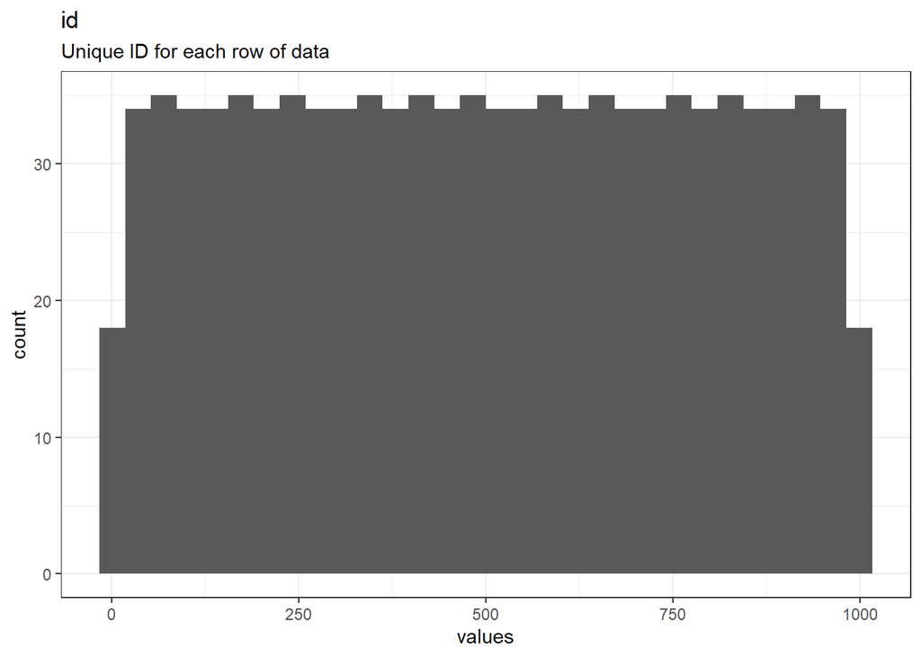

Distribution of values for id

0 missing values.

#### Summary statistics

| name | label | data_type | n_missing | complete_rate | min | median | max | mean | sd | hist |
| --- | --- | --- | --- | --- | --- | --- | --- | --- | --- | --- |
| id | Unique ID for each row of data | numeric | 0 | 1 | 1 | 500 | 999 | 500 | 288.5308 | ▇▇▇▇▇ |

### year

Year in which plot was assessed for FHB

#### Distribution

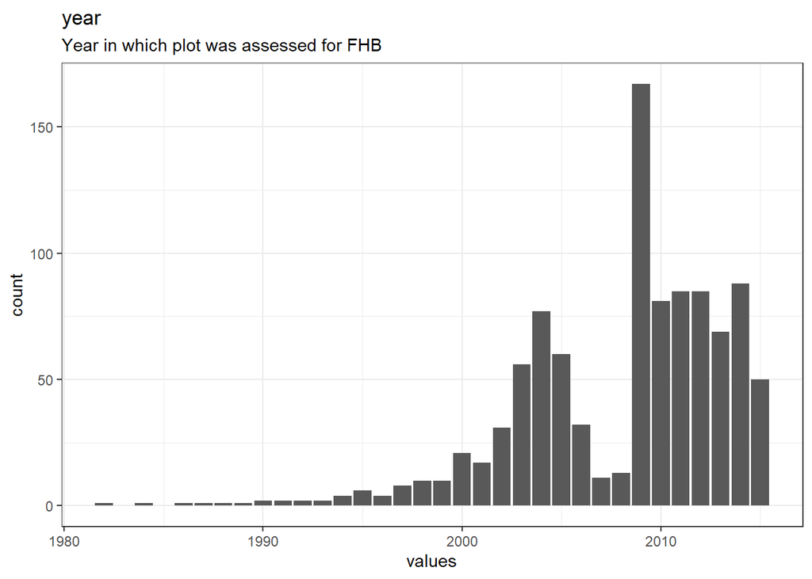

Distribution of values for year

0 missing values.

#### Summary statistics

| name | label | data_type | n_missing | complete_rate | min | median | max | mean | sd | hist |
| --- | --- | --- | --- | --- | --- | --- | --- | --- | --- | --- |
| year | Year in which plot was assessed for FHB | numeric | 0 | 1 | 1982 | 2009 | 2015 | 2008.107 | 5.184911 | ▁▁▁▃▇ |

### state

US state in which the plot was located

#### Distribution

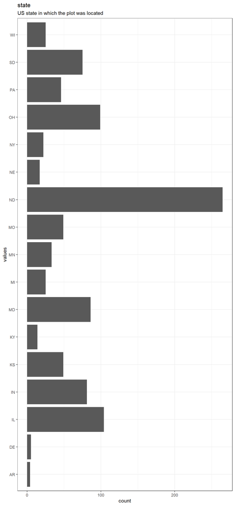

Distribution of values for state

0 missing values.

#### Summary statistics

| name | label | data_type | ordered | value_labels | n_missing | complete_rate | n_unique | top_counts |
| --- | --- | --- | --- | --- | --- | --- | --- | --- |
| state | US state in which the plot was located | factor | FALSE | 1. AR, 2. DE, 3. IL, 4. IN, 5. KS, 6. KY, 7. MD, 8. MI, 9. MN, 10. MO, 11. ND, 12. NE, 13. NY, 14. OH, 15. PA, 16. SD, 17. WI | 0 | 1 | 17 | ND: 265, IL: 104, OH: 99, MD: 86 |

### fdate

Anthesis date as a date-time variable in UTC

#### Distribution

```
## 426  unique, categorical values, so not shown.
```

0 missing values.

#### Summary statistics

| name | label | data_type | n_missing | complete_rate | n_unique | min | median | max |
| --- | --- | --- | --- | --- | --- | --- | --- | --- |
| fdate | Anthesis date as a date-time variable in UTC | POSIXct | 0 | 1 | 426 | 1982-05-26 | 2009-06-07 | 2015-07-14 |

### type

Spring wheat or winter wheat

#### Distribution

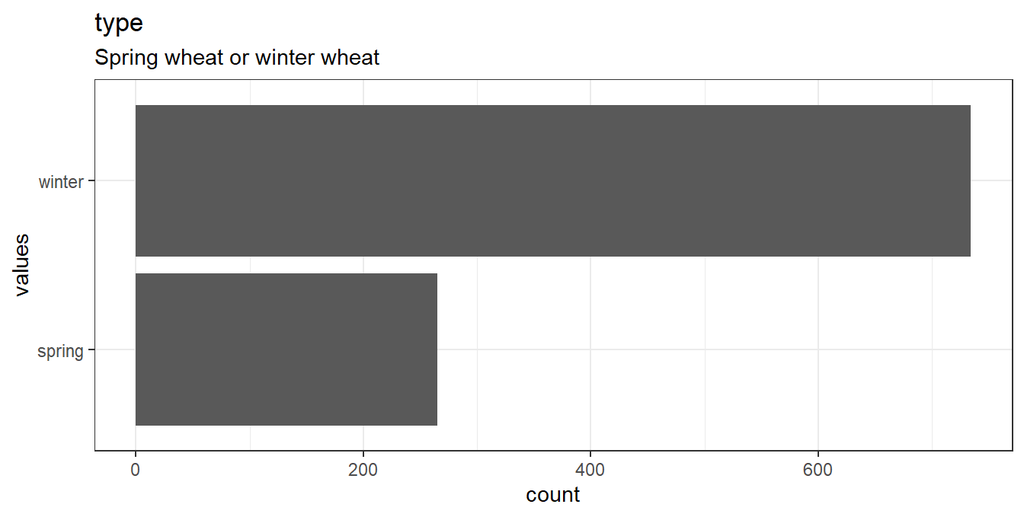

Distribution of values for type

0 missing values.

#### Summary statistics

| name | label | data_type | ordered | value_labels | n_missing | complete_rate | n_unique | top_counts |
| --- | --- | --- | --- | --- | --- | --- | --- | --- |
| type | Spring wheat or winter wheat | factor | FALSE | 1. spring, 2. winter | 0 | 1 | 2 | win: 734, spr: 265 |

### resist

Ordinal variable categorizing resistance of the cultivar to FHB; VS = very susceptible, S = susceptible, MS = moderately susceptible, MR = moderately resistant

#### Distribution

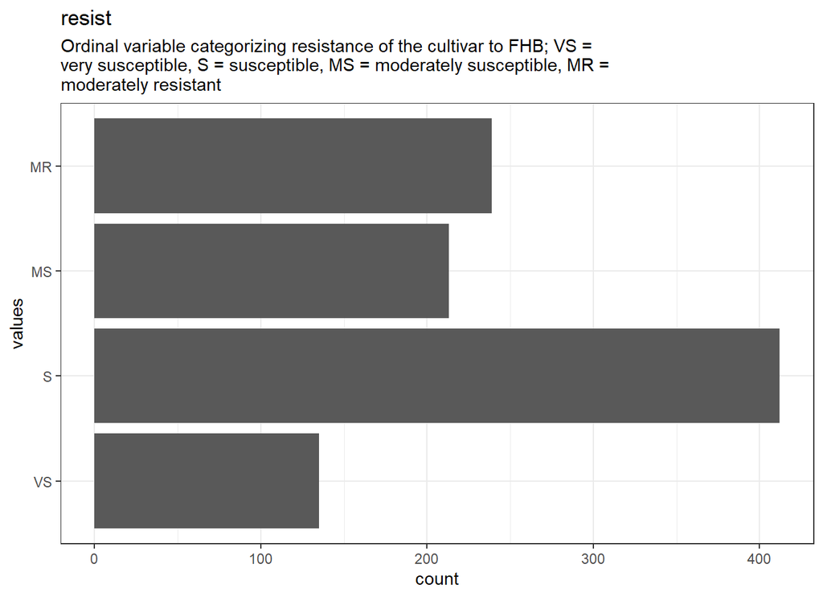

Distribution of values for resist

0 missing values.

#### Summary statistics

| name | label | data_type | ordered | value_labels | n_missing | complete_rate | n_unique | top_counts |
| --- | --- | --- | --- | --- | --- | --- | --- | --- |
| resist | Ordinal variable categorizing resistance of the cultivar to FHB; VS = very susceptible, S = susceptible, MS = moderately susceptible, MR = moderately resistant | factor | FALSE | 1. VS, 2. S, 3. MS, 4. MR | 0 | 1 | 4 | S: 412, MR: 239, MS: 213, VS: 135 |

### corn

Presence of some level of corn residue in the plot (1), or absence of any corn residue (0)

#### Distribution

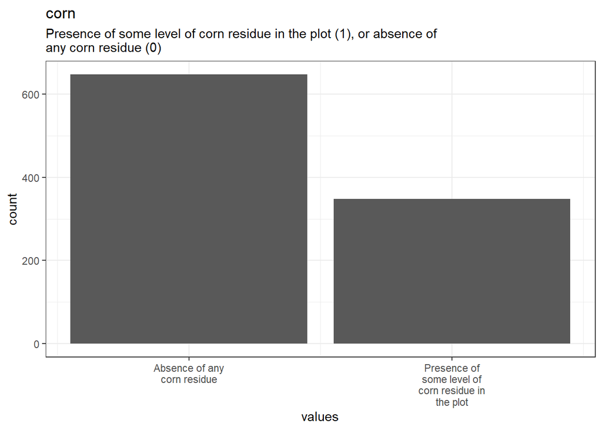

Distribution of values for corn

4 missing values.

#### Summary statistics

| name | label | data_type | n_missing | complete_rate | min | median | max | mean | sd | n_value_labels | hist |
| --- | --- | --- | --- | --- | --- | --- | --- | --- | --- | --- | --- |
| corn | Presence of some level of corn residue in the plot (1), or absence of any corn residue (0) | haven_labelled | 4 | 0.995996 | 0 | 0 | 1 | 0.3497487 | 0.4771303 | 2 | ▇▁▁▁▁▁▁▅ |

#### Value labels

Response choices

| name | value |
| --- | --- |
| Absence of any corn residue | 0 |
| Presence of some level of corn residue in the plot | 1 |

### S

FHB index, or severity of FHB symptoms on the spike (as a percentage)

#### Distribution

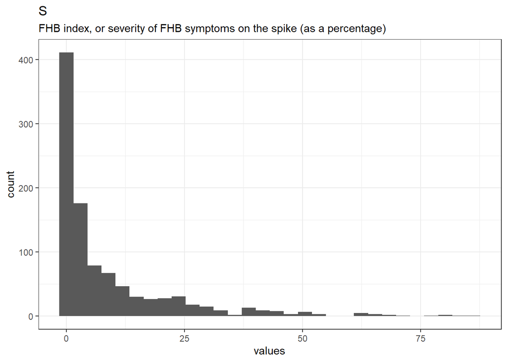

Distribution of values for S

0 missing values.

#### Summary statistics

| name | label | data_type | n_missing | complete_rate | min | median | max | mean | sd | hist |
| --- | --- | --- | --- | --- | --- | --- | --- | --- | --- | --- |
| S | FHB index, or severity of FHB symptoms on the spike (as a percentage) | numeric | 0 | 1 | 0 | 2.9 | 86 | 8.813017 | 13.70341 | ▇▁▁▁▁ |

### T.A.1

Mean daily air temperature (T; °C), 25 d to 15 d pre-anthesis

#### Distribution

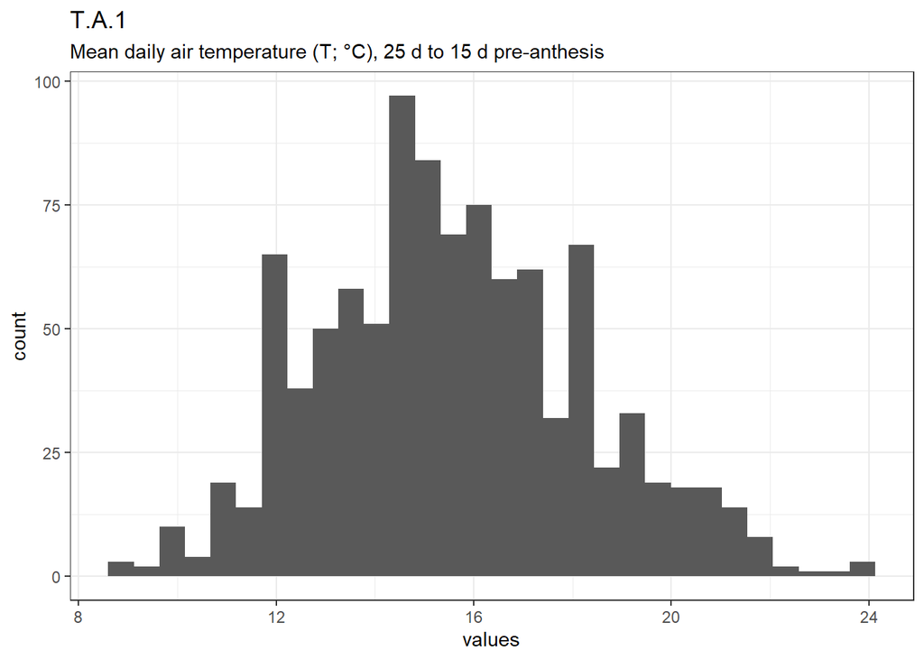

Distribution of values for T.A.1

0 missing values.

#### Summary statistics

| name | label | data_type | n_missing | complete_rate | min | median | max | mean | sd | hist |
| --- | --- | --- | --- | --- | --- | --- | --- | --- | --- | --- |
| T.A.1 | Mean daily air temperature (T; °C), 25 d to 15 d pre-anthesis | numeric | 0 | 1 | 8.9 | 15 | 24 | 15.56725 | 2.684923 | ▂▇▇▃▁ |

### T.A.2

Mean daily T (°C), 20 d to 10 d pre-anthesis

#### Distribution

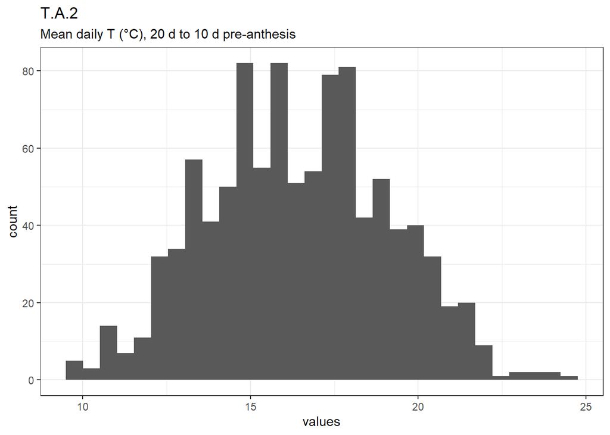

Distribution of values for T.A.2

0 missing values.

#### Summary statistics

| name | label | data_type | n_missing | complete_rate | min | median | max | mean | sd | hist |
| --- | --- | --- | --- | --- | --- | --- | --- | --- | --- | --- |
| T.A.2 | Mean daily T (°C), 20 d to 10 d pre-anthesis | numeric | 0 | 1 | 9.8 | 16 | 24 | 16.42836 | 2.676531 | ▂▇▇▅▁ |

### T.A.3

Mean daily T (°C), 40 d to 30 d pre-anthesis

#### Distribution

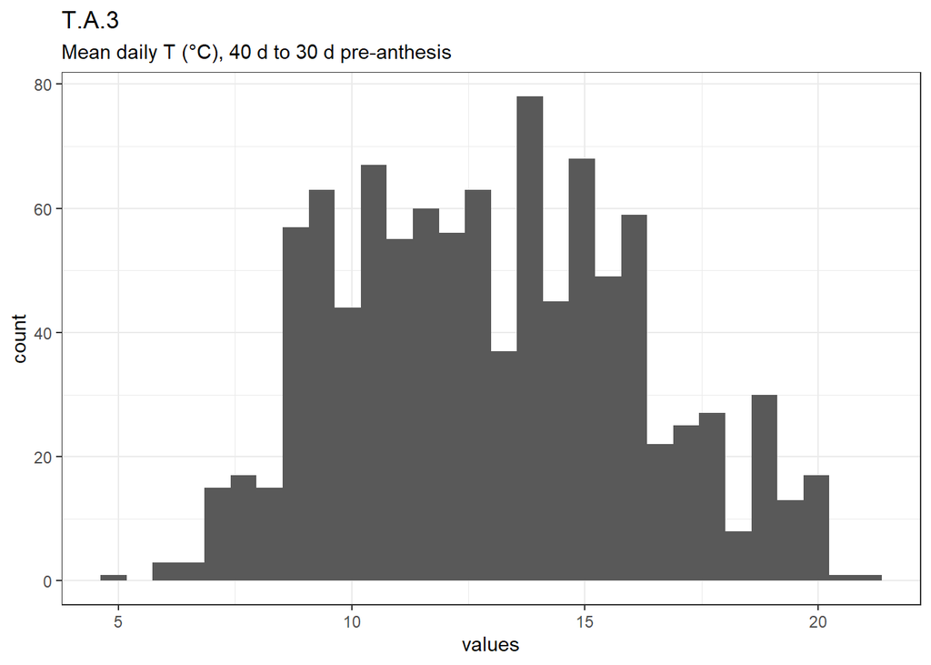

Distribution of values for T.A.3

0 missing values.

#### Summary statistics

| name | label | data_type | n_missing | complete_rate | min | median | max | mean | sd | hist |
| --- | --- | --- | --- | --- | --- | --- | --- | --- | --- | --- |
| T.A.3 | Mean daily T (°C), 40 d to 30 d pre-anthesis | numeric | 0 | 1 | 4.9 | 13 | 21 | 12.99076 | 3.172911 | ▁▇▇▆▂ |

### T.A.4

Mean daily T (°C), anthesis to 10 d post-anthesis

#### Distribution

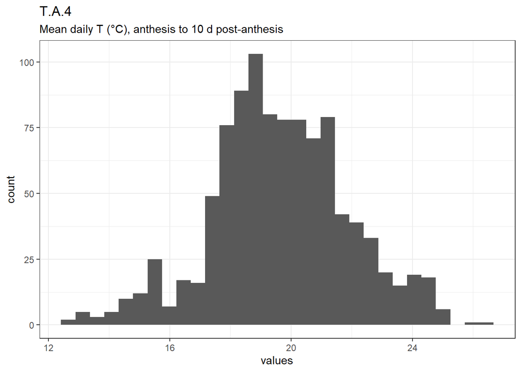

Distribution of values for T.A.4

0 missing values.

#### Summary statistics

| name | label | data_type | n_missing | complete_rate | min | median | max | mean | sd | hist |
| --- | --- | --- | --- | --- | --- | --- | --- | --- | --- | --- |
| T.A.4 | Mean daily T (°C), anthesis to 10 d post-anthesis | numeric | 0 | 1 | 13 | 20 | 26 | 19.63348 | 2.273392 | ▁▃▇▃▁ |

### T.A.5

Mean daily T (°C), anthesis to 20 d post-anthesis

#### Distribution

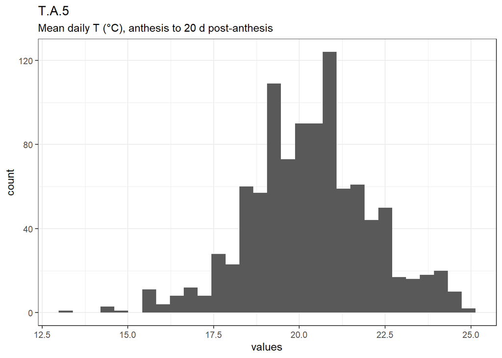

Distribution of values for T.A.5

0 missing values.

#### Summary statistics

| name | label | data_type | n_missing | complete_rate | min | median | max | mean | sd | hist |
| --- | --- | --- | --- | --- | --- | --- | --- | --- | --- | --- |
| T.A.5 | Mean daily T (°C), anthesis to 20 d post-anthesis | numeric | 0 | 1 | 13 | 20 | 25 | 20.30667 | 1.804347 | ▁▁▇▇▂ |

### D.A.1

Mean daily dewpoint (D; °C), 20 d pre-anthesis to anthesis

#### Distribution

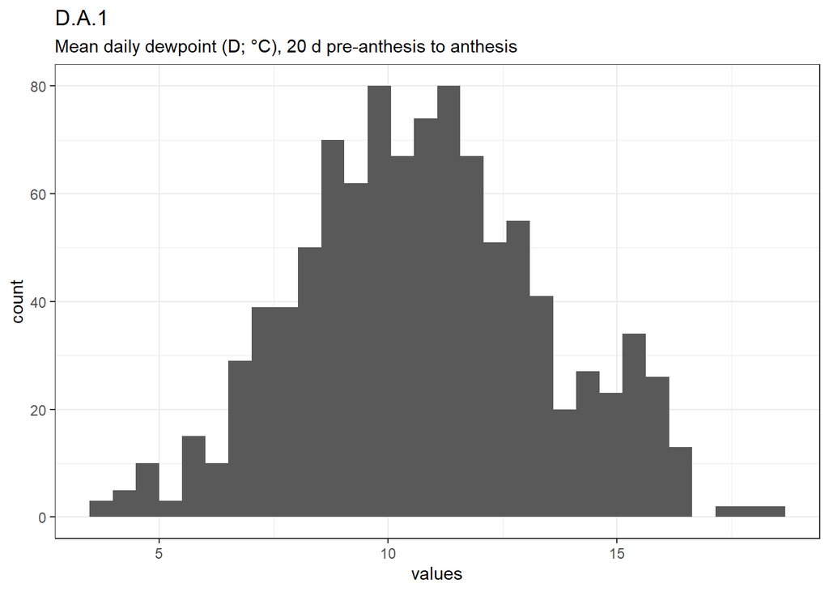

Distribution of values for D.A.1

0 missing values.

#### Summary statistics

| name | label | data_type | n_missing | complete_rate | min | median | max | mean | sd | hist |
| --- | --- | --- | --- | --- | --- | --- | --- | --- | --- | --- |
| D.A.1 | Mean daily dewpoint (D; °C), 20 d pre-anthesis to anthesis | numeric | 0 | 1 | 3.7 | 11 | 18 | 10.75427 | 2.690609 | ▁▆▇▃▁ |

### D.A.2

Mean daily D (°C), 20 d to 10 d pre-anthesis

#### Distribution

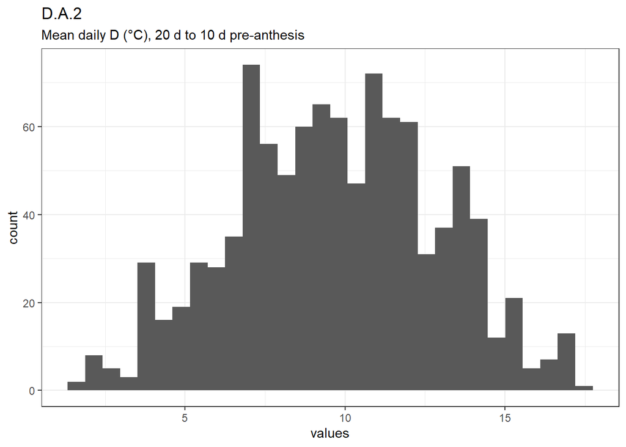

Distribution of values for D.A.2

0 missing values.

#### Summary statistics

| name | label | data_type | n_missing | complete_rate | min | median | max | mean | sd | hist |
| --- | --- | --- | --- | --- | --- | --- | --- | --- | --- | --- |
| D.A.2 | Mean daily D (°C), 20 d to 10 d pre-anthesis | numeric | 0 | 1 | 1.6 | 9.8 | 17 | 9.728791 | 3.185607 | ▂▆▇▇▂ |

### D.A.3

Mean daily D (°C), 40 d to 25d pre-anthesis

#### Distribution

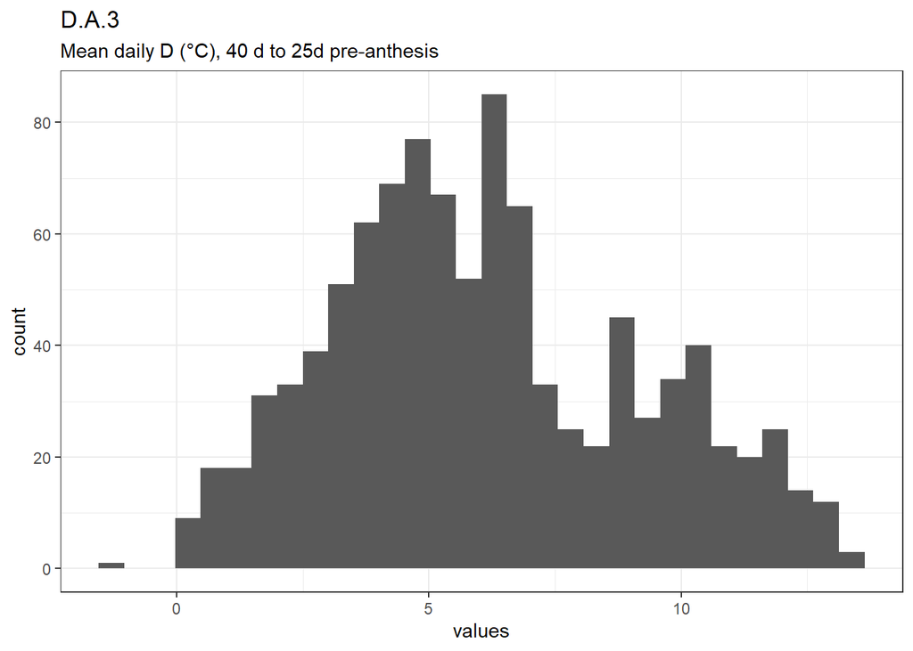

Distribution of values for D.A.3

0 missing values.

#### Summary statistics

| name | label | data_type | n_missing | complete_rate | min | median | max | mean | sd | hist |
| --- | --- | --- | --- | --- | --- | --- | --- | --- | --- | --- |
| D.A.3 | Mean daily D (°C), 40 d to 25d pre-anthesis | numeric | 0 | 1 | -1.3 | 5.7 | 13 | 6.107057 | 3.0366 | ▁▆▇▅▂ |

### P.A.1

Mean daily barometric pressure (P; hPa), 40 d to 20 d pre-anthesis

#### Distribution

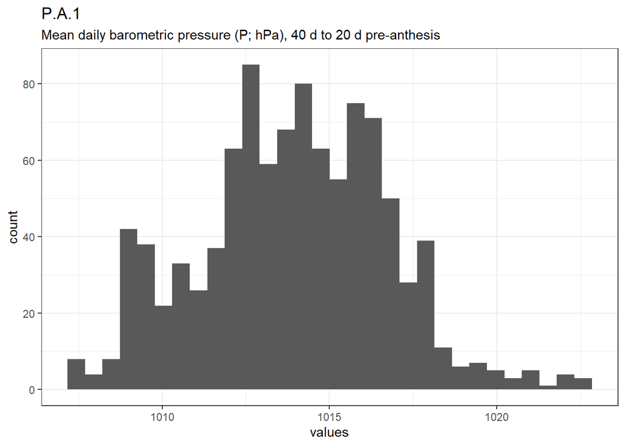

Distribution of values for P.A.1

0 missing values.

#### Summary statistics

| name | label | data_type | n_missing | complete_rate | min | median | max | mean | sd | hist |
| --- | --- | --- | --- | --- | --- | --- | --- | --- | --- | --- |
| P.A.1 | Mean daily barometric pressure (P; hPa), 40 d to 20 d pre-anthesis | numeric | 0 | 1 | 1007 | 1014 | 1023 | 1013.911 | 2.794784 | ▃▆▇▃▁ |

### P.A.2

Mean daily P (hPa), 45 d to 35 d pre-anthesis

#### Distribution

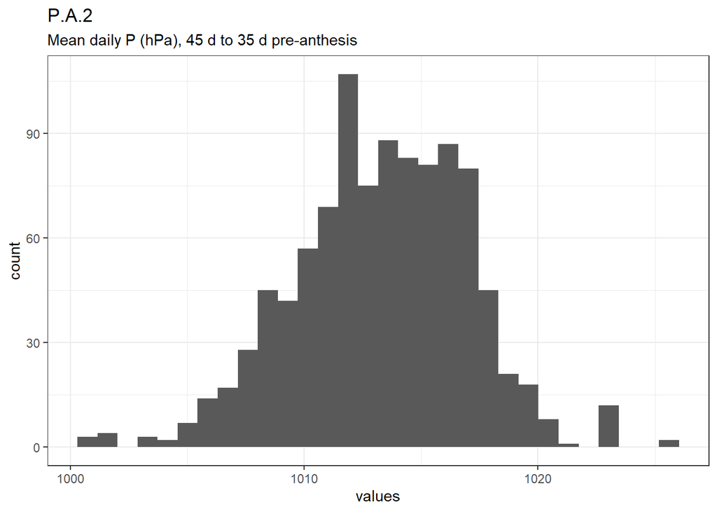

Distribution of values for P.A.2

0 missing values.

#### Summary statistics

| name | label | data_type | n_missing | complete_rate | min | median | max | mean | sd | hist |
| --- | --- | --- | --- | --- | --- | --- | --- | --- | --- | --- |
| P.A.2 | Mean daily P (hPa), 45 d to 35 d pre-anthesis | numeric | 0 | 1 | 1001 | 1013 | 1026 | 1013.279 | 3.692072 | ▁▃▇▅▁ |

### P.A.3

Mean daily P (hPa), 60 d to 50 d pre-anthesis

#### Distribution

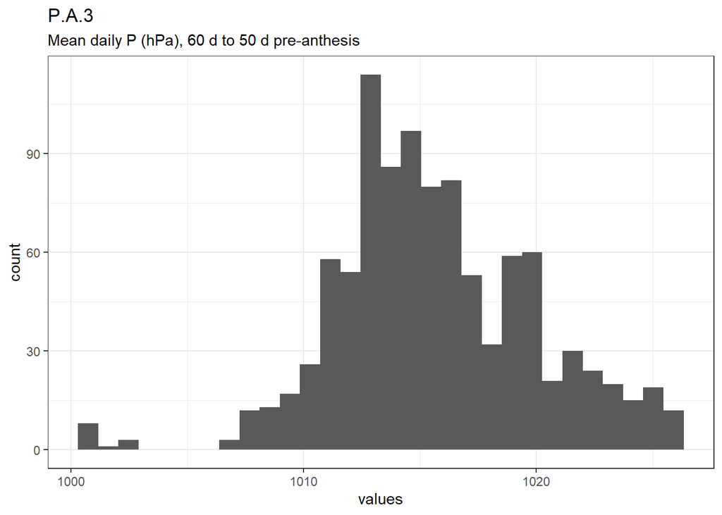

Distribution of values for P.A.3

0 missing values.

#### Summary statistics

| name | label | data_type | n_missing | complete_rate | min | median | max | mean | sd | hist |
| --- | --- | --- | --- | --- | --- | --- | --- | --- | --- | --- |
| P.A.3 | Mean daily P (hPa), 60 d to 50 d pre-anthesis | numeric | 0 | 1 | 1001 | 1015 | 1026 | 1015.637 | 4.298716 | ▁▁▇▅▂ |

### P.A.4

Mean daily P (hPa), 80d to 70 d pre-anthesis

#### Distribution

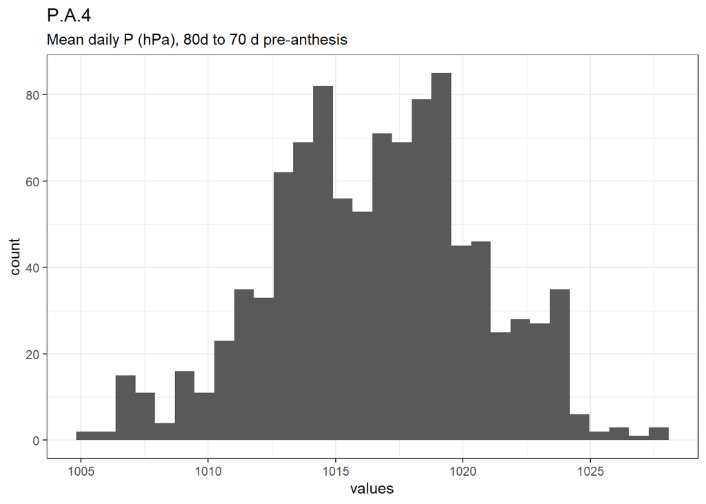

Distribution of values for P.A.4

0 missing values.

#### Summary statistics

| name | label | data_type | n_missing | complete_rate | min | median | max | mean | sd | hist |
| --- | --- | --- | --- | --- | --- | --- | --- | --- | --- | --- |
| P.A.4 | Mean daily P (hPa), 80d to 70 d pre-anthesis | numeric | 0 | 1 | 1005 | 1017 | 1028 | 1016.551 | 4.082377 | ▁▅▇▅▁ |

### P.A.5

Mean daily P (hPa), 100d to 60 d pre-anthesis

#### Distribution

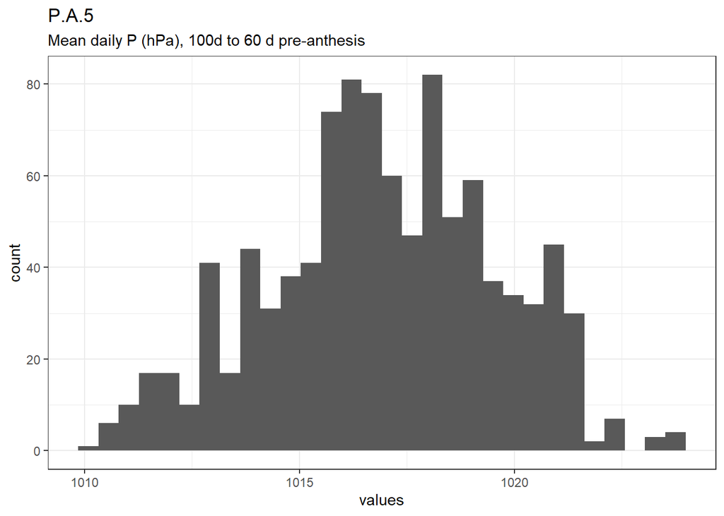

Distribution of values for P.A.5

0 missing values.

#### Summary statistics

| name | label | data_type | n_missing | complete_rate | min | median | max | mean | sd | hist |
| --- | --- | --- | --- | --- | --- | --- | --- | --- | --- | --- |
| P.A.5 | Mean daily P (hPa), 100d to 60 d pre-anthesis | numeric | 0 | 1 | 1010 | 1017 | 1024 | 1016.918 | 2.652055 | ▂▃▇▅▁ |

### RH.A.1

Mean daily relative humidity (RH; %), 20 d pre-anthesis to anthesis

#### Distribution

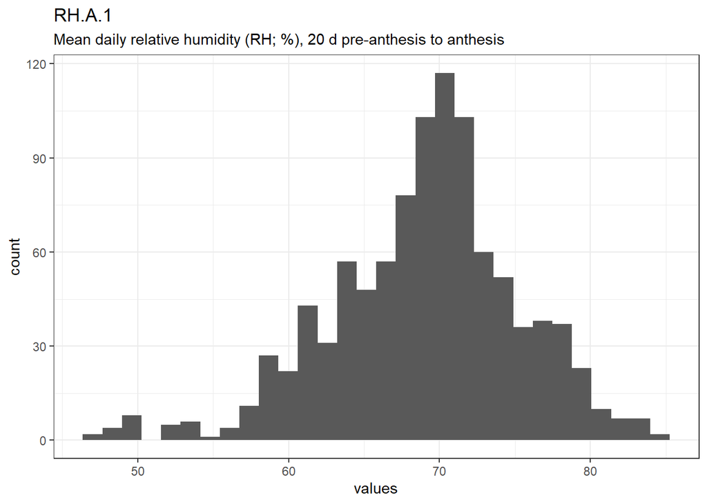

Distribution of values for RH.A.1

0 missing values.

#### Summary statistics

| name | label | data_type | n_missing | complete_rate | min | median | max | mean | sd | hist |
| --- | --- | --- | --- | --- | --- | --- | --- | --- | --- | --- |
| RH.A.1 | Mean daily relative humidity (RH; %), 20 d pre-anthesis to anthesis | numeric | 0 | 1 | 47 | 70 | 85 | 69.00439 | 6.279215 | ▁▂▇▇▂ |

### RH.A.2

Mean daily RH (%), anthesis to 10 d post-anthesis; same as RH10

#### Distribution

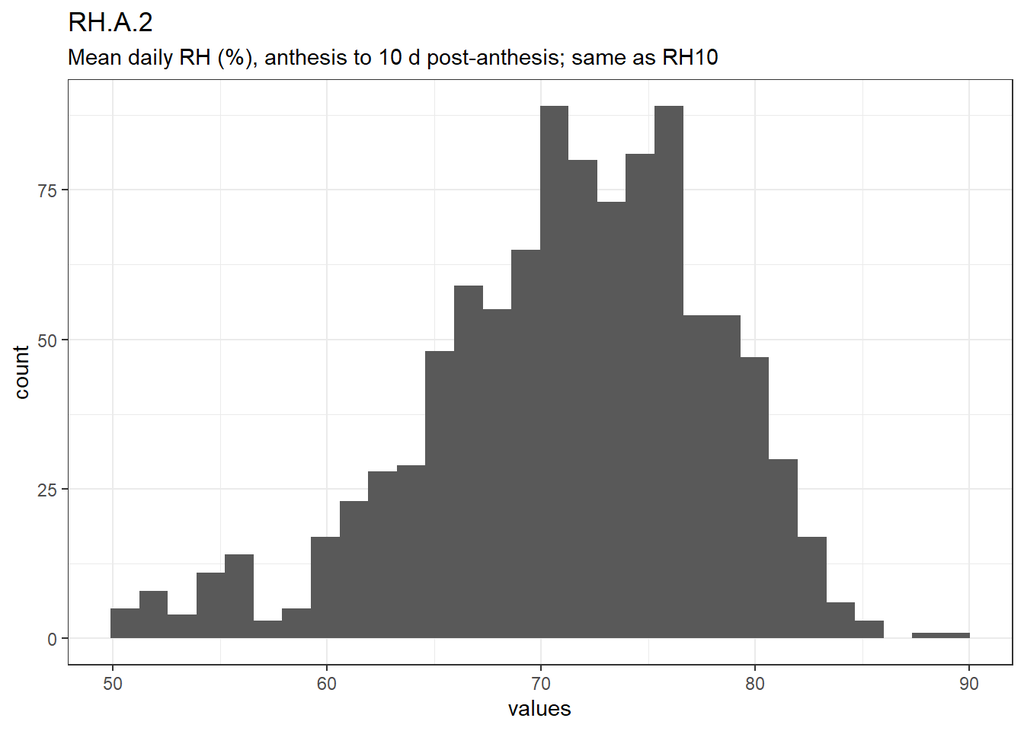

Distribution of values for RH.A.2

0 missing values.

#### Summary statistics

| name | label | data_type | n_missing | complete_rate | min | median | max | mean | sd | hist |
| --- | --- | --- | --- | --- | --- | --- | --- | --- | --- | --- |
| RH.A.2 | Mean daily RH (%), anthesis to 10 d post-anthesis; same as RH10 | numeric | 0 | 1 | 51 | 72 | 89 | 71.30815 | 6.697947 | ▁▃▇▇▁ |

### RH.A.3

Mean daily RH (%), 10 d pre-anthesis to 10 d post-anthesis

#### Distribution

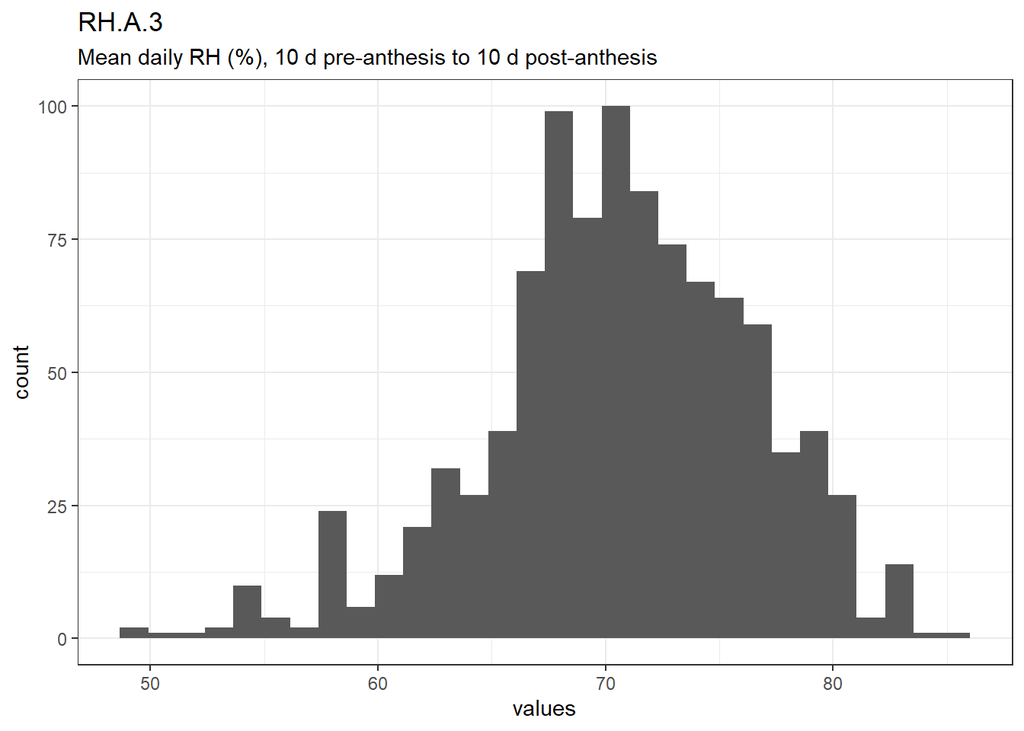

Distribution of values for RH.A.3

0 missing values.

#### Summary statistics

| name | label | data_type | n_missing | complete_rate | min | median | max | mean | sd | hist |
| --- | --- | --- | --- | --- | --- | --- | --- | --- | --- | --- |
| RH.A.3 | Mean daily RH (%), 10 d pre-anthesis to 10 d post-anthesis | numeric | 0 | 1 | 49 | 71 | 85 | 70.5574 | 5.913251 | ▁▂▇▇▂ |

### VPD.A.1

Mean daily vapor pressure deficit (VPD; kPa), 10 d pre-anthesis to anthesis

#### Distribution

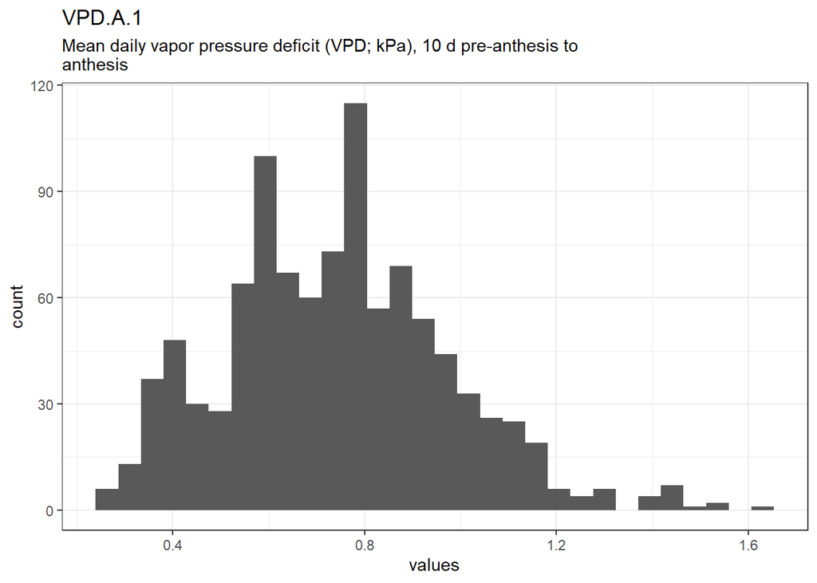

Distribution of values for VPD.A.1

0 missing values.

#### Summary statistics

| name | label | data_type | n_missing | complete_rate | min | median | max | mean | sd | hist |
| --- | --- | --- | --- | --- | --- | --- | --- | --- | --- | --- |
| VPD.A.1 | Mean daily vapor pressure deficit (VPD; kPa), 10 d pre-anthesis to anthesis | numeric | 0 | 1 | 0.26 | 0.74 | 1.6 | 0.7406627 | 0.2331558 | ▃▇▅▁▁ |

### VPD.A.2

Mean daily VPD (kPa), 20 d pre-anthesis to anthesis

#### Distribution

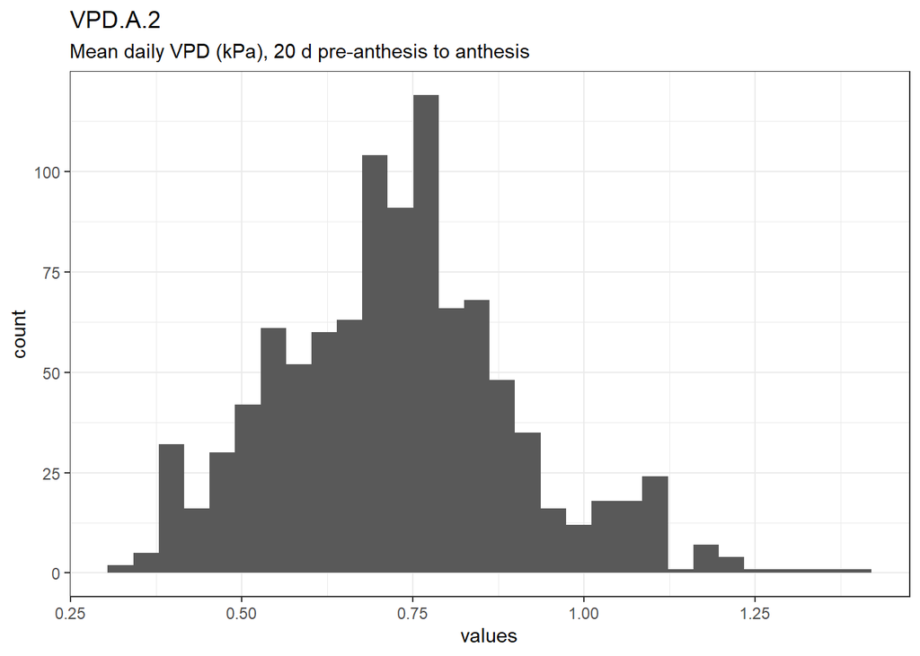

Distribution of values for VPD.A.2

0 missing values.

#### Summary statistics

| name | label | data_type | n_missing | complete_rate | min | median | max | mean | sd | hist |
| --- | --- | --- | --- | --- | --- | --- | --- | --- | --- | --- |
| VPD.A.2 | Mean daily VPD (kPa), 20 d pre-anthesis to anthesis | numeric | 0 | 1 | 0.32 | 0.73 | 1.4 | 0.7275932 | 0.1768509 | ▃▇▆▂▁ |

### VPD.A.3

Mean daily VPD (kPa), anthesis to 15 d post-anthesis

#### Distribution

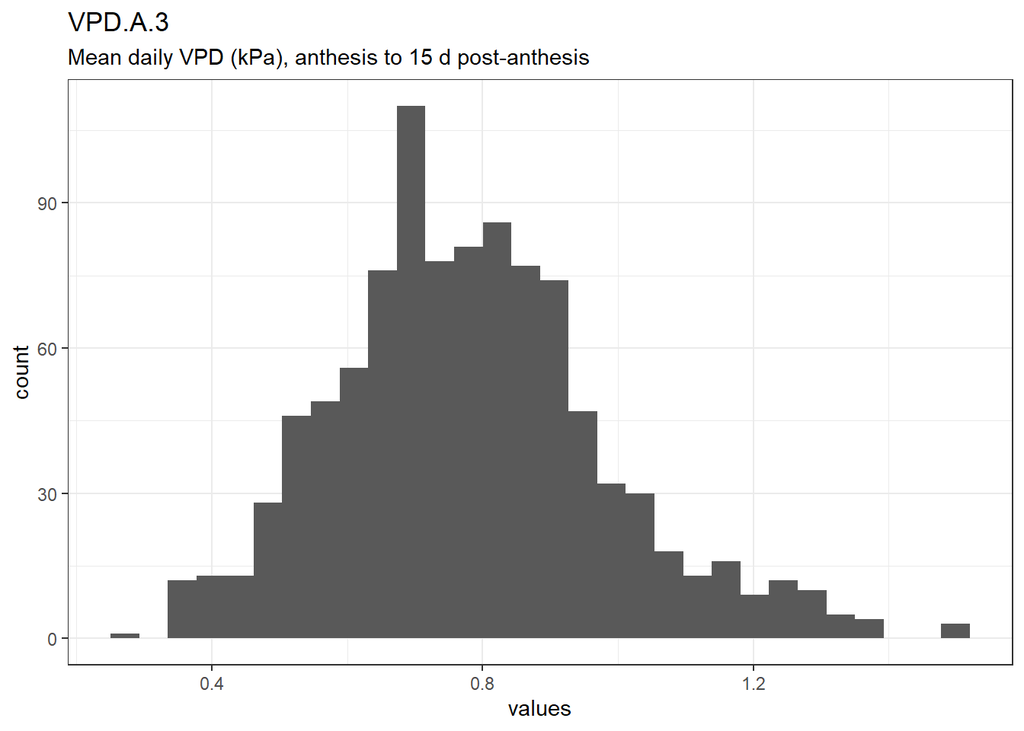

Distribution of values for VPD.A.3

0 missing values.

#### Summary statistics

| name | label | data_type | n_missing | complete_rate | min | median | max | mean | sd | hist |
| --- | --- | --- | --- | --- | --- | --- | --- | --- | --- | --- |
| VPD.A.3 | Mean daily VPD (kPa), anthesis to 15 d post-anthesis | numeric | 0 | 1 | 0.27 | 0.77 | 1.5 | 0.7815022 | 0.2012754 | ▂▇▇▂▁ |

### VPD.A.4

Mean daily VPD (kPa), anthesis to 20 d post-anthesis

#### Distribution

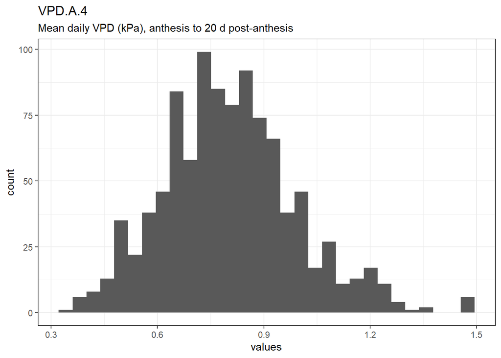

Distribution of values for VPD.A.4

0 missing values.

#### Summary statistics

| name | label | data_type | n_missing | complete_rate | min | median | max | mean | sd | hist |
| --- | --- | --- | --- | --- | --- | --- | --- | --- | --- | --- |
| VPD.A.4 | Mean daily VPD (kPa), anthesis to 20 d post-anthesis | numeric | 0 | 1 | 0.34 | 0.8 | 1.5 | 0.8022981 | 0.189444 | ▂▇▇▂▁ |

### VPD.A.5

Mean daily VPD (kPa), 10 d pre-anthesis to 10 d post-anthesis

#### Distribution

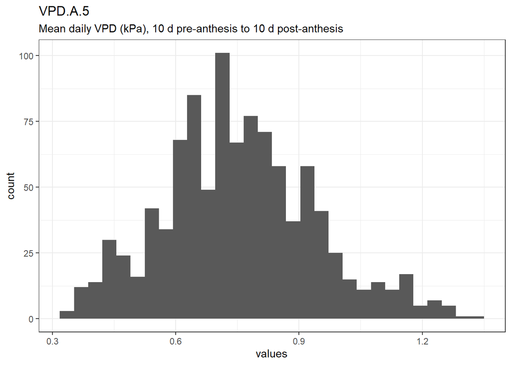

Distribution of values for VPD.A.5

0 missing values.

#### Summary statistics

| name | label | data_type | n_missing | complete_rate | min | median | max | mean | sd | hist |
| --- | --- | --- | --- | --- | --- | --- | --- | --- | --- | --- |
| VPD.A.5 | Mean daily VPD (kPa), 10 d pre-anthesis to 10 d post-anthesis | numeric | 0 | 1 | 0.34 | 0.75 | 1.3 | 0.7543922 | 0.1852515 | ▂▇▇▂▁ |

### TDD.A.1

Mean daily temperature-dewpoint depression (TDD; °C), 20 d pre-anthesis to anthesis

#### Distribution

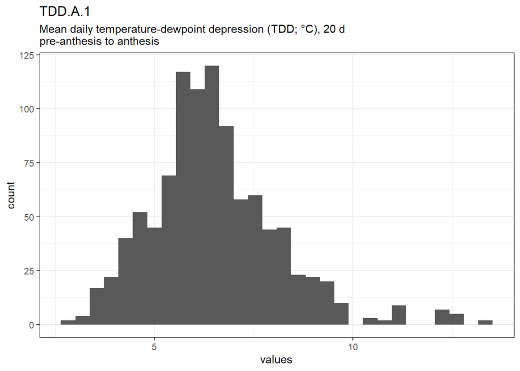

Distribution of values for TDD.A.1

0 missing values.

#### Summary statistics

| name | label | data_type | n_missing | complete_rate | min | median | max | mean | sd | hist |
| --- | --- | --- | --- | --- | --- | --- | --- | --- | --- | --- |
| TDD.A.1 | Mean daily temperature-dewpoint depression (TDD; °C), 20 d pre-anthesis to anthesis | numeric | 0 | 1 | 2.8 | 6.3 | 13 | 6.508824 | 1.623532 | ▂▇▃▁▁ |

### TDD.A.2

Mean daily TDD (°C), 30 d pre-anthesis to anthesis

#### Distribution

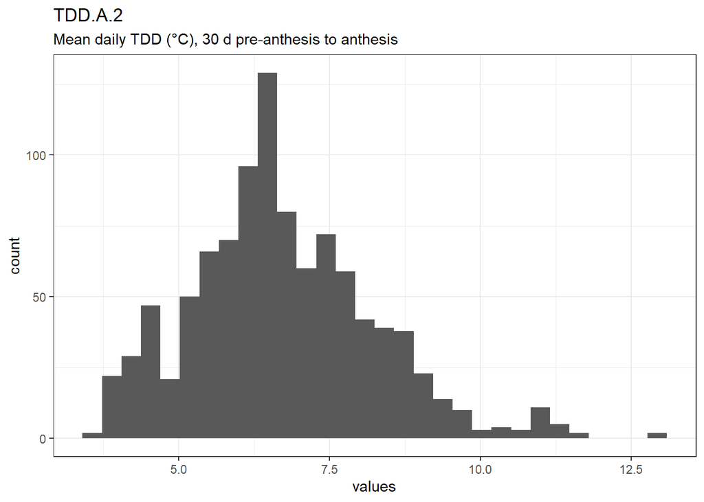

Distribution of values for TDD.A.2

0 missing values.

#### Summary statistics

| name | label | data_type | n_missing | complete_rate | min | median | max | mean | sd | hist |
| --- | --- | --- | --- | --- | --- | --- | --- | --- | --- | --- |
| TDD.A.2 | Mean daily TDD (°C), 30 d pre-anthesis to anthesis | numeric | 0 | 1 | 3.6 | 6.5 | 13 | 6.717713 | 1.522374 | ▃▇▅▁▁ |

### TDD.A.3

Mean daily TDD (°C), anthesis to 10 d post-anthesis

#### Distribution

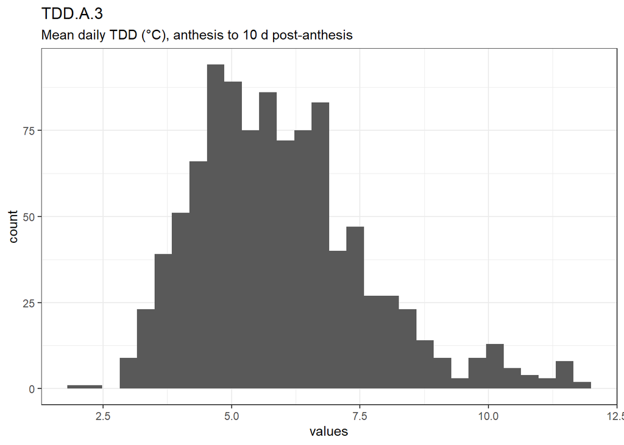

Distribution of values for TDD.A.3

0 missing values.

#### Summary statistics

| name | label | data_type | n_missing | complete_rate | min | median | max | mean | sd | hist |
| --- | --- | --- | --- | --- | --- | --- | --- | --- | --- | --- |
| TDD.A.3 | Mean daily TDD (°C), anthesis to 10 d post-anthesis | numeric | 0 | 1 | 2 | 5.8 | 12 | 5.964873 | 1.688219 | ▂▇▆▂▁ |

### TDD.A.4

Mean daily TDD (°C), anthesis to 20 d post-anthesis

#### Distribution

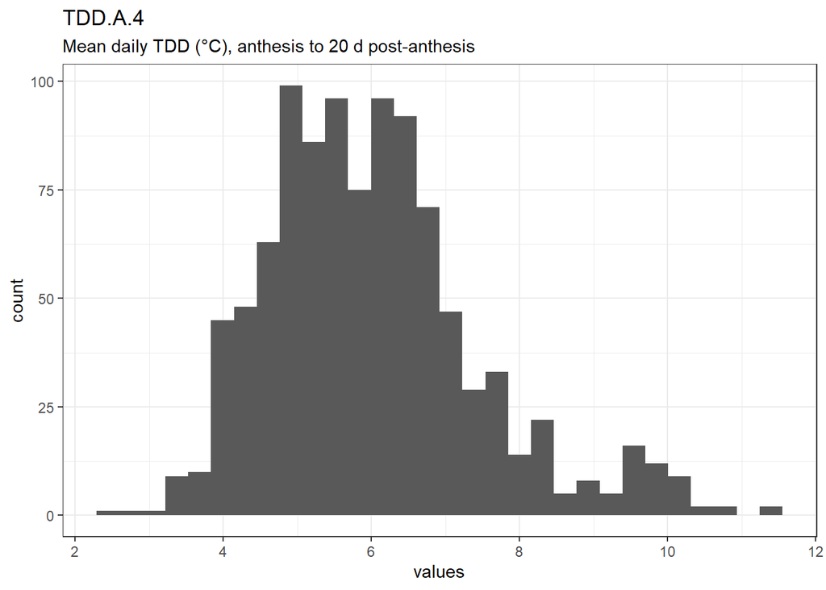

Distribution of values for TDD.A.4

0 missing values.

#### Summary statistics

| name | label | data_type | n_missing | complete_rate | min | median | max | mean | sd | hist |
| --- | --- | --- | --- | --- | --- | --- | --- | --- | --- | --- |
| TDD.A.4 | Mean daily TDD (°C), anthesis to 20 d post-anthesis | numeric | 0 | 1 | 2.4 | 5.8 | 11 | 6.010466 | 1.440745 | ▂▇▆▁▁ |

### TDD.A.5

Mean daily TDD (°C), 10 d pre-anthesis to 5 d post-anthesis

#### Distribution

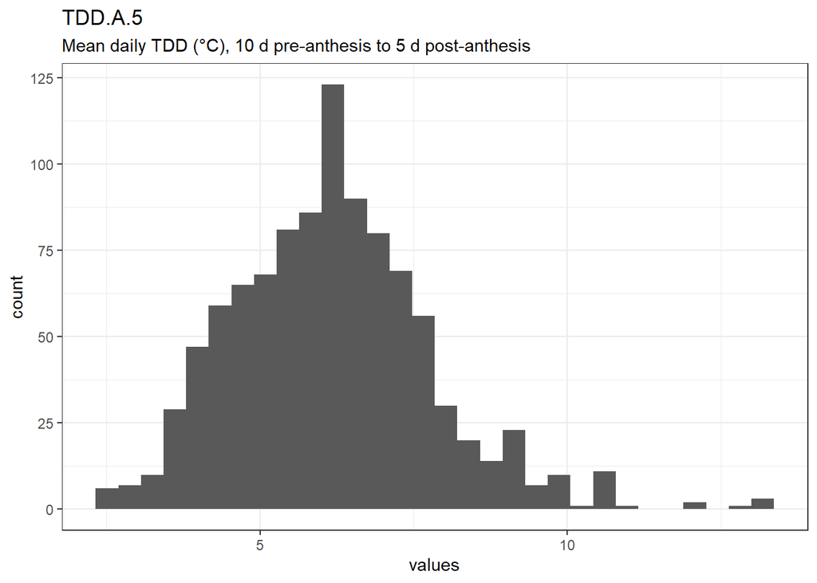

Distribution of values for TDD.A.5

0 missing values.

#### Summary statistics

| name | label | data_type | n_missing | complete_rate | min | median | max | mean | sd | hist |
| --- | --- | --- | --- | --- | --- | --- | --- | --- | --- | --- |
| TDD.A.5 | Mean daily TDD (°C), 10 d pre-anthesis to 5 d post-anthesis | numeric | 0 | 1 | 2.5 | 6.1 | 13 | 6.177004 | 1.625121 | ▃▇▅▁▁ |

### TDD.A.6

Mean daily TDD (°C), 10 d pre-anthesis to 10 d post-anthesis

#### Distribution

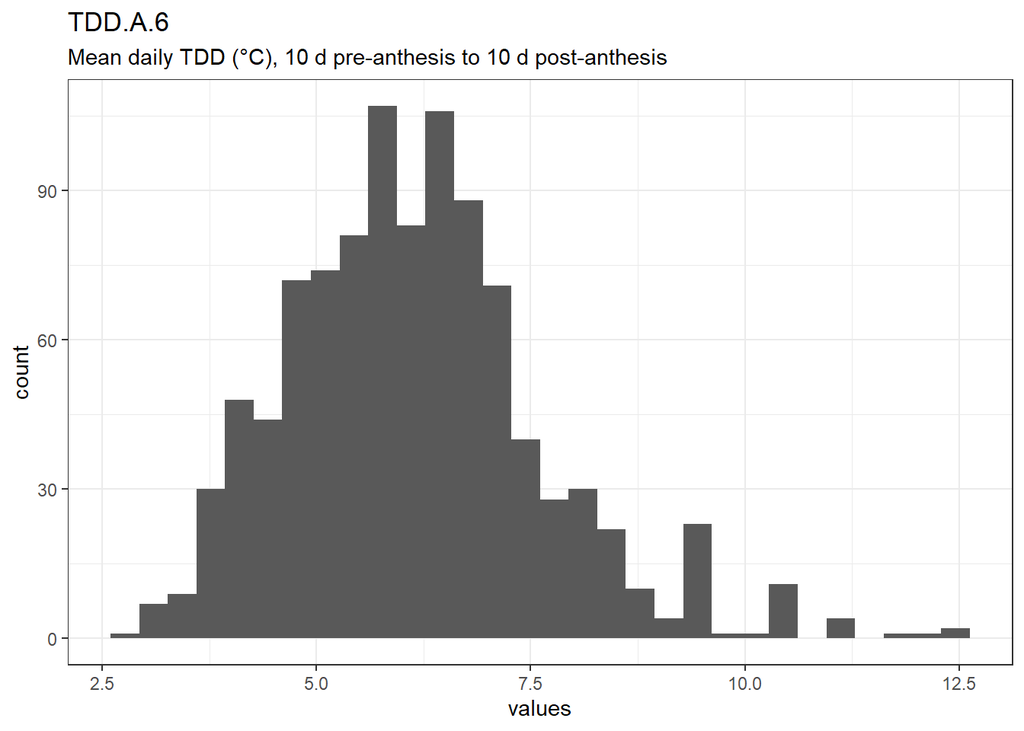

Distribution of values for TDD.A.6

0 missing values.

#### Summary statistics

| name | label | data_type | n_missing | complete_rate | min | median | max | mean | sd | hist |
| --- | --- | --- | --- | --- | --- | --- | --- | --- | --- | --- |
| TDD.A.6 | Mean daily TDD (°C), 10 d pre-anthesis to 10 d post-anthesis | numeric | 0 | 1 | 2.8 | 6 | 12 | 6.148087 | 1.495161 | ▂▇▅▁▁ |

### RH.G80.CHD.1

No. hr (RH $\geq$ 80%), 20 d pre-anthesis to anthesis

#### Distribution

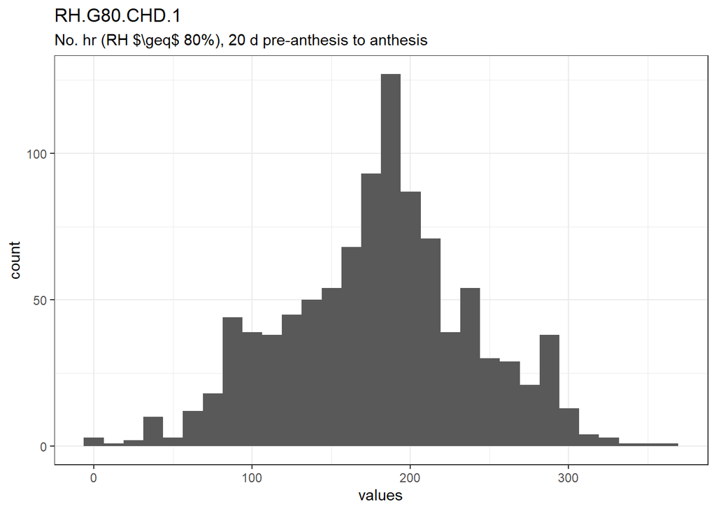

Distribution of values for RH.G80.CHD.1

0 missing values.

#### Summary statistics

| name | label | data_type | n_missing | complete_rate | min | median | max | mean | sd | hist |
| --- | --- | --- | --- | --- | --- | --- | --- | --- | --- | --- |
| RH.G80.CHD.1 | No. hr (RH $\geq$ 80%), 20 d pre-anthesis to anthesis | numeric | 0 | 1 | 0 | 183 | 363 | 180.1672 | 60.50636 | ▁▅▇▃▁ |

### RH.G80.CHD.2

No. hr (RH $\geq$ 80%), anthesis to 10 d post-anthesis

#### Distribution

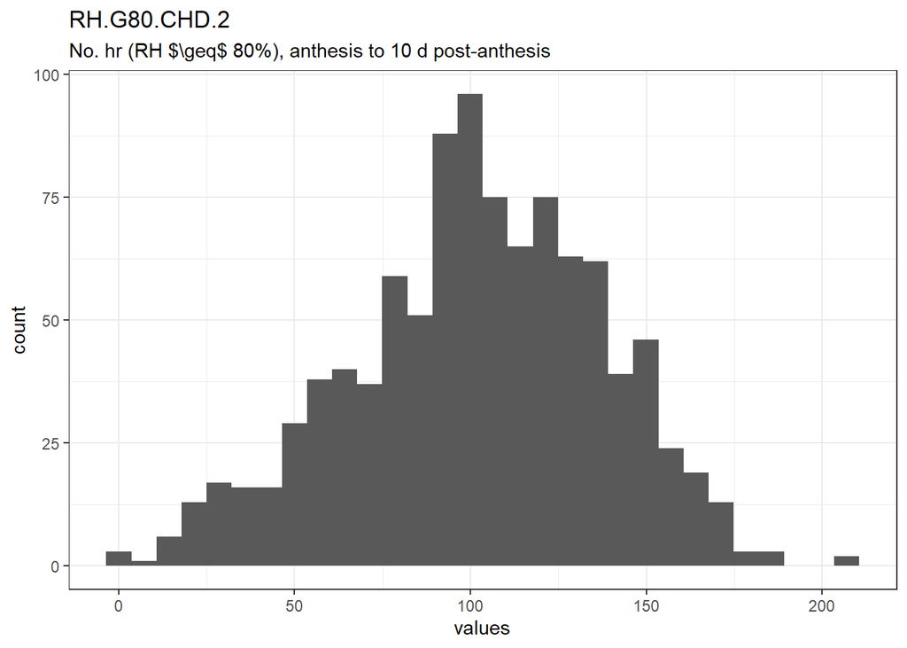

Distribution of values for RH.G80.CHD.2

0 missing values.

#### Summary statistics

| name | label | data_type | n_missing | complete_rate | min | median | max | mean | sd | hist |
| --- | --- | --- | --- | --- | --- | --- | --- | --- | --- | --- |
| RH.G80.CHD.2 | No. hr (RH $\geq$ 80%), anthesis to 10 d post-anthesis | numeric | 0 | 1 | 0 | 103 | 207 | 101.8649 | 35.84154 | ▁▃▇▅▁ |

### RH.G80.CHD.3

No. hr (RH $\geq$ 80%), 20 d pre-anthesis to 10 d post-anthesis

#### Distribution

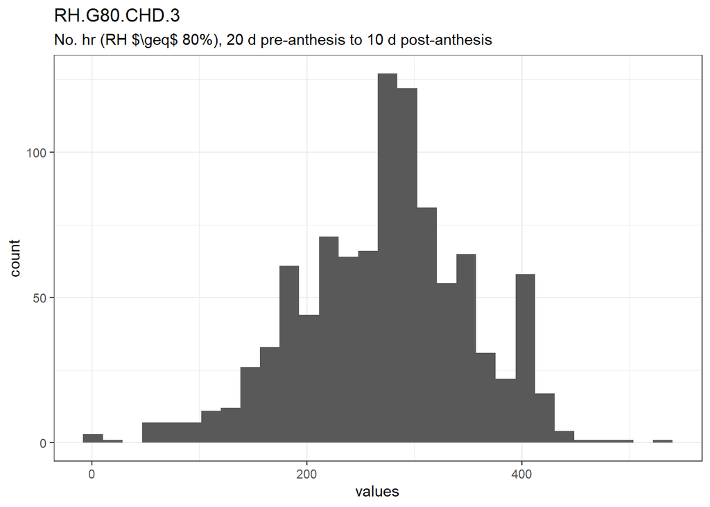

Distribution of values for RH.G80.CHD.3

0 missing values.

#### Summary statistics

| name | label | data_type | n_missing | complete_rate | min | median | max | mean | sd | hist |
| --- | --- | --- | --- | --- | --- | --- | --- | --- | --- | --- |
| RH.G80.CHD.3 | No. hr (RH $\geq$ 80%), 20 d pre-anthesis to 10 d post-anthesis | numeric | 0 | 1 | 1 | 279 | 531 | 272.5716 | 80.23589 | ▁▃▇▃▁ |

### RH.G90.CHD.1

No. hr (RH $\geq$ 90%), 20 d pre-anthesis to anthesis

#### Distribution

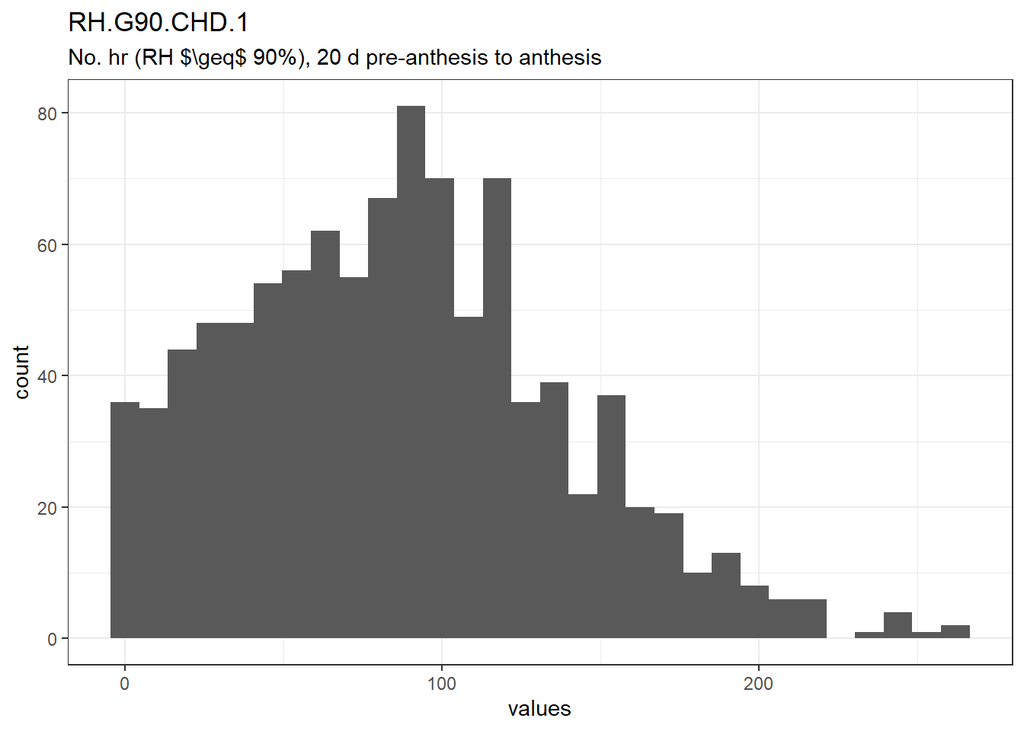

Distribution of values for RH.G90.CHD.1

0 missing values.

#### Summary statistics

| name | label | data_type | n_missing | complete_rate | min | median | max | mean | sd | hist |
| --- | --- | --- | --- | --- | --- | --- | --- | --- | --- | --- |
| RH.G90.CHD.1 | No. hr (RH $\geq$ 90%), 20 d pre-anthesis to anthesis | numeric | 0 | 1 | 0 | 84 | 262 | 86.35536 | 51.35035 | ▆▇▅▂▁ |

### RH.G90.CHD.2

No. hr (RH $\geq$ 90%), anthesis to 10 d post-anthesis

#### Distribution

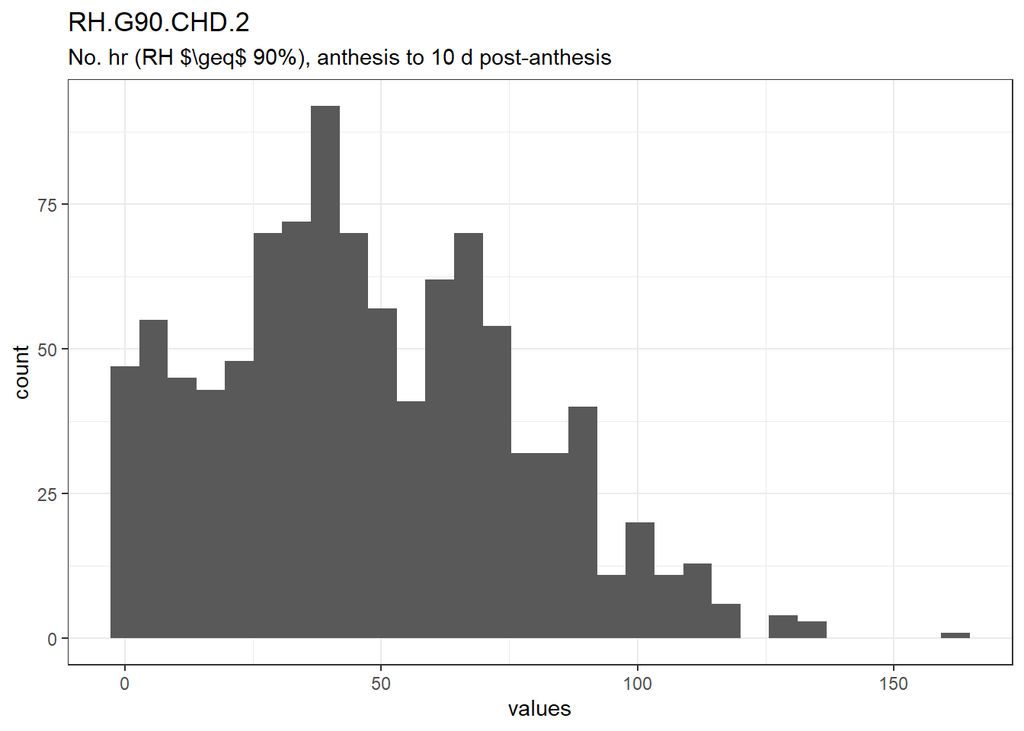

Distribution of values for RH.G90.CHD.2

0 missing values.

#### Summary statistics

| name | label | data_type | n_missing | complete_rate | min | median | max | mean | sd | hist |
| --- | --- | --- | --- | --- | --- | --- | --- | --- | --- | --- |
| RH.G90.CHD.2 | No. hr (RH $\geq$ 90%), anthesis to 10 d post-anthesis | numeric | 0 | 1 | 0 | 43 | 162 | 47.49149 | 29.50513 | ▇▇▅▁▁ |

### RH.G90.CHD.3

No. hr (RH $\geq$ 90%), 50 d pre-anthesis to 10 d post-anthesis

#### Distribution

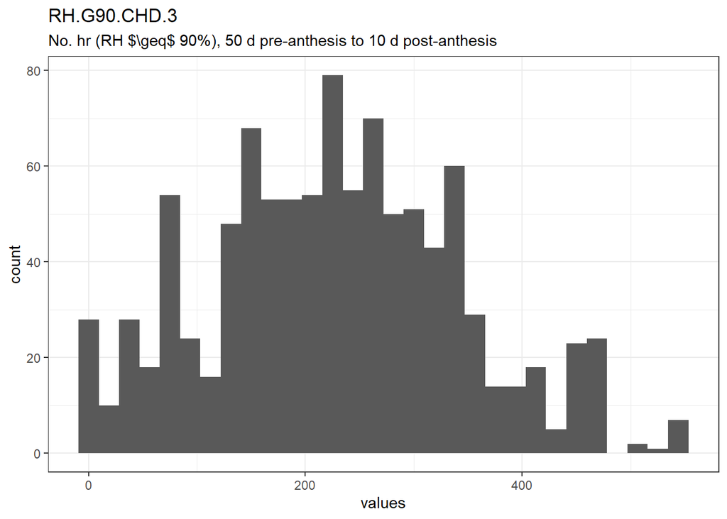

Distribution of values for RH.G90.CHD.3

0 missing values.

#### Summary statistics

| name | label | data_type | n_missing | complete_rate | min | median | max | mean | sd | hist |
| --- | --- | --- | --- | --- | --- | --- | --- | --- | --- | --- |
| RH.G90.CHD.3 | No. hr (RH $\geq$ 90%), 50 d pre-anthesis to 10 d post-anthesis | numeric | 0 | 1 | 0 | 225 | 544 | 227.2282 | 116.5551 | ▃▇▇▃▂ |

### T.G30.CHD.1

No. hr (T > 30°C), 20 d pre-anthesis to anthesis

#### Distribution

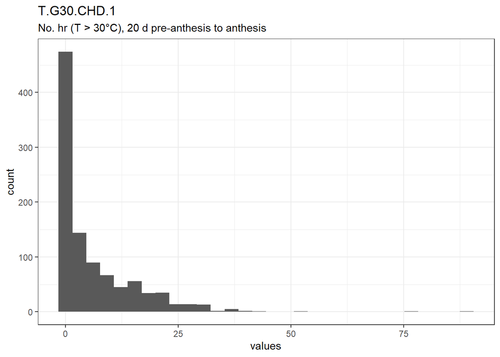

Distribution of values for T.G30.CHD.1

0 missing values.

#### Summary statistics

| name | label | data_type | n_missing | complete_rate | min | median | max | mean | sd | hist |
| --- | --- | --- | --- | --- | --- | --- | --- | --- | --- | --- |
| T.G30.CHD.1 | No. hr (T > 30°C), 20 d pre-anthesis to anthesis | numeric | 0 | 1 | 0 | 2 | 89 | 6.172172 | 9.084241 | ▇▁▁▁▁ |

### T.G30.CHD.2

No. hr (T > 30°C), 60 d to 40 d pre-anthesis

#### Distribution

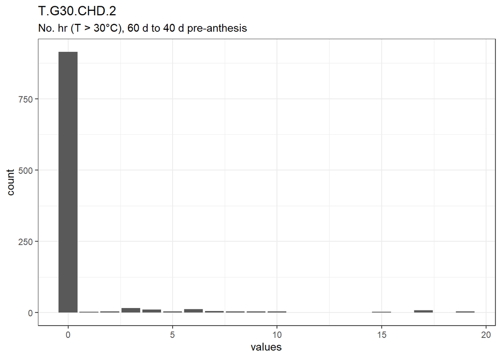

Distribution of values for T.G30.CHD.2

0 missing values.

#### Summary statistics

| name | label | data_type | n_missing | complete_rate | min | median | max | mean | sd | hist |
| --- | --- | --- | --- | --- | --- | --- | --- | --- | --- | --- |
| T.G30.CHD.2 | No. hr (T > 30°C), 60 d to 40 d pre-anthesis | numeric | 0 | 1 | 0 | 0 | 19 | 0.6226226 | 2.530521 | ▇▁▁▁▁ |

### T.G30.CHD.3

No. hr (T > 30°C), 10 d to 20 d post-anthesis

#### Distribution

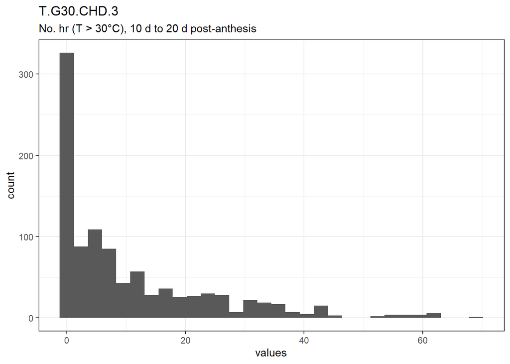

Distribution of values for T.G30.CHD.3

0 missing values.

#### Summary statistics

| name | label | data_type | n_missing | complete_rate | min | median | max | mean | sd | hist |
| --- | --- | --- | --- | --- | --- | --- | --- | --- | --- | --- |
| T.G30.CHD.3 | No. hr (T > 30°C), 10 d to 20 d post-anthesis | numeric | 0 | 1 | 0 | 5 | 69 | 10.60561 | 13.22166 | ▇▂▁▁▁ |

### TRH.15T30nRHG80.CHD.1

No. hr (15°C $\leq$ T $\leq$ 30°C & RH $\geq$ 80%), 30 d pre-anthesis to anthesis

#### Distribution

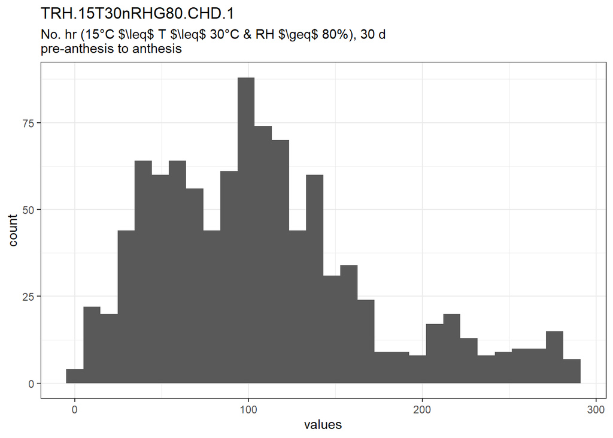

Distribution of values for TRH.15T30nRHG80.CHD.1

0 missing values.

#### Summary statistics

| name | label | data_type | n_missing | complete_rate | min | median | max | mean | sd | hist |
| --- | --- | --- | --- | --- | --- | --- | --- | --- | --- | --- |
| TRH.15T30nRHG80.CHD.1 | No. hr (15°C $\leq$ T $\leq$ 30°C & RH $\geq$ 80%), 30 d pre-anthesis to anthesis | numeric | 0 | 1 | 0 | 100 | 286 | 107.978 | 63.08956 | ▅▇▆▂▂ |

### TRH.15T30nRHG80.CHD.2

No. hr (15°C $\leq$ T $\leq$ 30°C & RH $\geq$ 80%), 60 d to 40 d pre-anthesis

#### Distribution

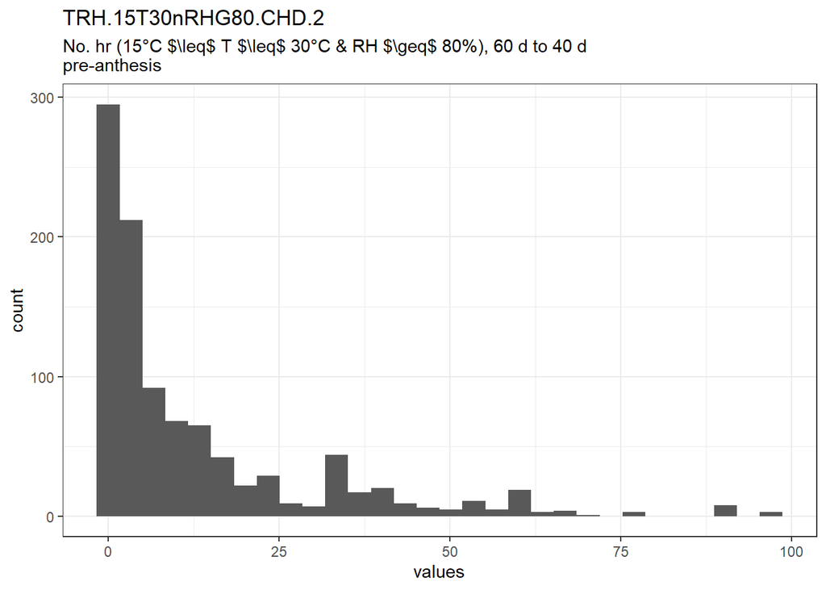

Distribution of values for TRH.15T30nRHG80.CHD.2

0 missing values.

#### Summary statistics

| name | label | data_type | n_missing | complete_rate | min | median | max | mean | sd | hist |
| --- | --- | --- | --- | --- | --- | --- | --- | --- | --- | --- |
| TRH.15T30nRHG80.CHD.2 | No. hr (15°C $\leq$ T $\leq$ 30°C & RH $\geq$ 80%), 60 d to 40 d pre-anthesis | numeric | 0 | 1 | 0 | 5 | 97 | 12.91692 | 17.84121 | ▇▁▁▁▁ |

### TRH.15T30nRHG80.CHD.3

No. hr (15°C $\leq$ T $\leq$ 30°C & RH $\geq$ 80%), anthesis to 10 d post-anthesis

#### Distribution

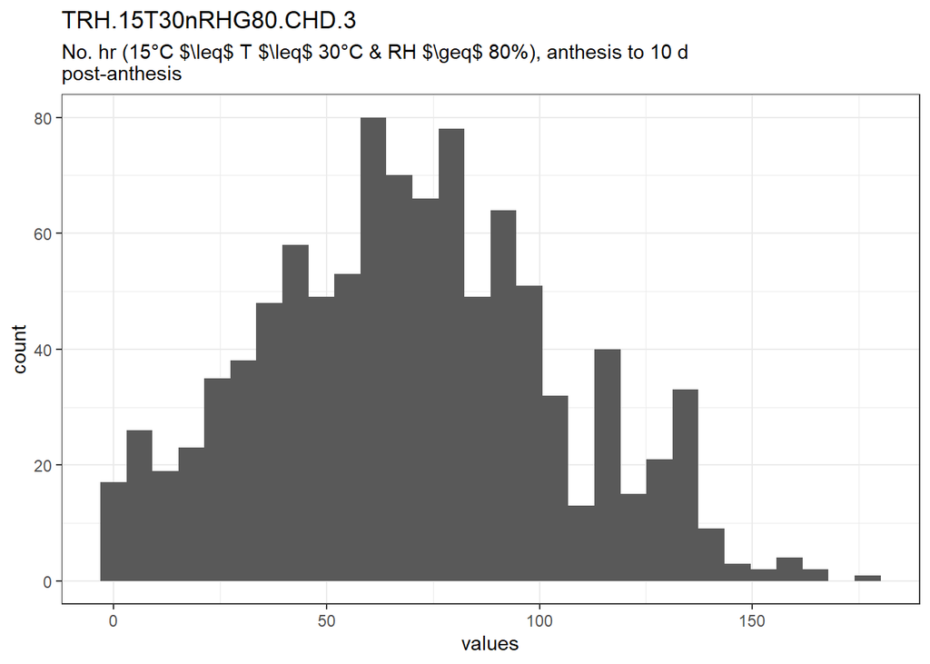

Distribution of values for TRH.15T30nRHG80.CHD.3

0 missing values.

#### Summary statistics

| name | label | data_type | n_missing | complete_rate | min | median | max | mean | sd | hist |
| --- | --- | --- | --- | --- | --- | --- | --- | --- | --- | --- |
| TRH.15T30nRHG80.CHD.3 | No. hr (15°C $\leq$ T $\leq$ 30°C & RH $\geq$ 80%), anthesis to 10 d post-anthesis | numeric | 0 | 1 | 0 | 69 | 177 | 69.48949 | 34.62513 | ▃▇▇▃▁ |

### TRH.15T30nRHG90.CHD.1

No. hr (15°C $\leq$ T $\leq$ 30°C & RH $\geq$ 90%), 30 d pre-anthesis to anthesis

#### Distribution

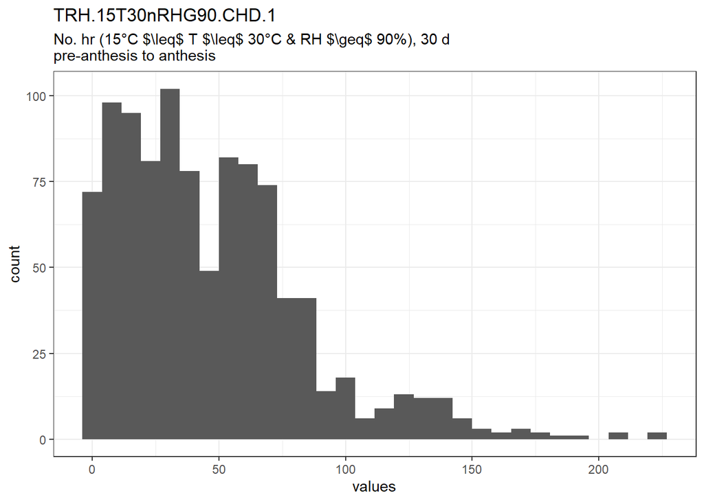

Distribution of values for TRH.15T30nRHG90.CHD.1

0 missing values.

#### Summary statistics

| name | label | data_type | n_missing | complete_rate | min | median | max | mean | sd | hist |
| --- | --- | --- | --- | --- | --- | --- | --- | --- | --- | --- |
| TRH.15T30nRHG90.CHD.1 | No. hr (15°C $\leq$ T $\leq$ 30°C & RH $\geq$ 90%), 30 d pre-anthesis to anthesis | numeric | 0 | 1 | 0 | 41 | 223 | 47.0961 | 37.21124 | ▇▅▁▁▁ |

### TRH.15T30nRHG90.CHD.2

No. hr (15°C $\leq$ T $\leq$ 30°C & RH $\geq$ 90%), 60 d to 40 d pre-anthesis

#### Distribution

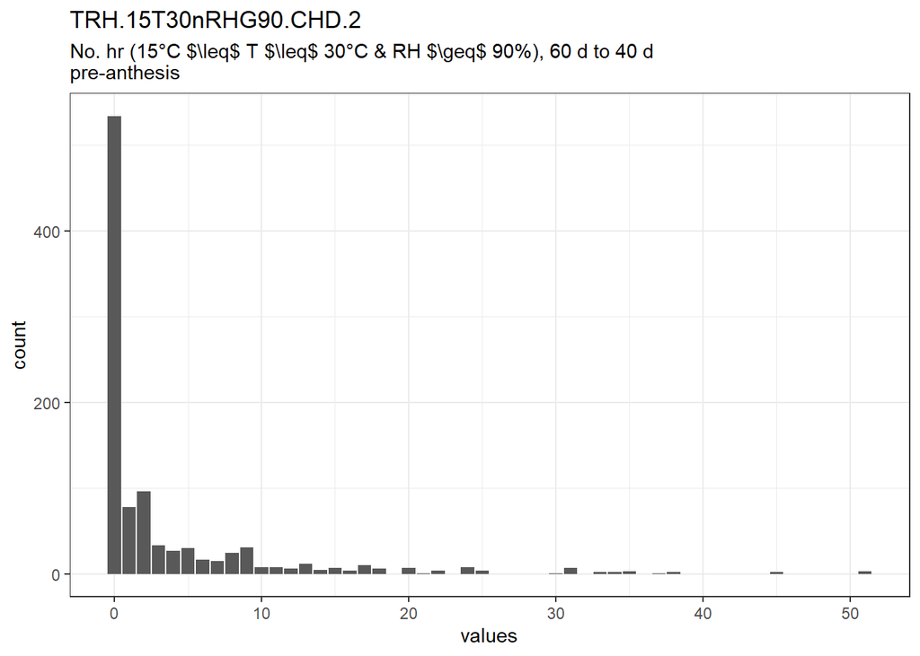

Distribution of values for TRH.15T30nRHG90.CHD.2

0 missing values.

#### Summary statistics

| name | label | data_type | n_missing | complete_rate | min | median | max | mean | sd | hist |
| --- | --- | --- | --- | --- | --- | --- | --- | --- | --- | --- |
| TRH.15T30nRHG90.CHD.2 | No. hr (15°C $\leq$ T $\leq$ 30°C & RH $\geq$ 90%), 60 d to 40 d pre-anthesis | numeric | 0 | 1 | 0 | 0 | 51 | 3.612613 | 7.191977 | ▇▁▁▁▁ |

### TRH.15T30nRHG90.CHD.3

No. hr (15°C $\leq$ T $\leq$ 30°C & RH $\geq$ 90%), anthesis to 10 d post-anthesis

#### Distribution

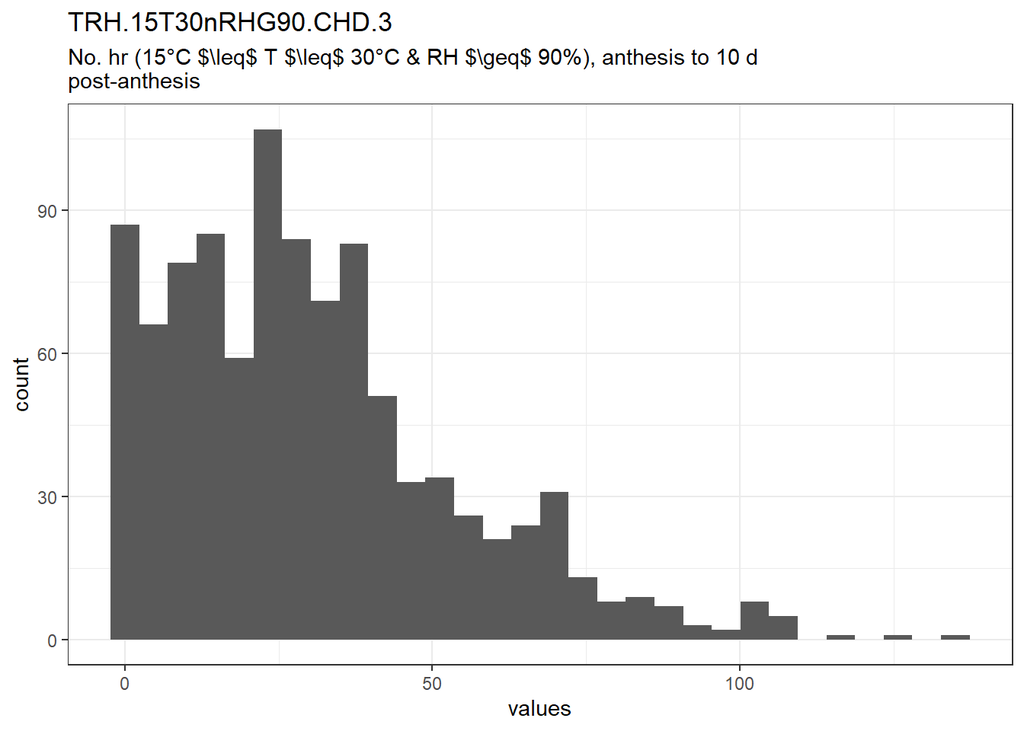

Distribution of values for TRH.15T30nRHG90.CHD.3

0 missing values.

#### Summary statistics

| name | label | data_type | n_missing | complete_rate | min | median | max | mean | sd | hist |
| --- | --- | --- | --- | --- | --- | --- | --- | --- | --- | --- |
| TRH.15T30nRHG90.CHD.3 | No. hr (15°C $\leq$ T $\leq$ 30°C & RH $\geq$ 90%), anthesis to 10 d post-anthesis | numeric | 0 | 1 | 0 | 27 | 135 | 30.50651 | 23.66021 | ▇▅▂▁▁ |

### TRH.20T25nRHG85.CHD.1

No. hr (20°C $\leq$ T $\leq$ 25°C & RH $\geq$ 85%), anthesis to 10 d post-anthesis

#### Distribution

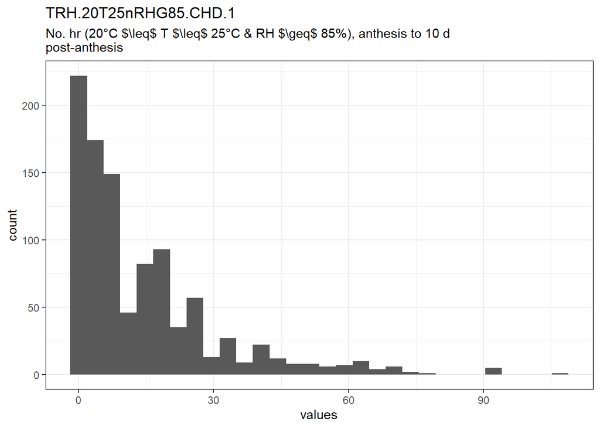

Distribution of values for TRH.20T25nRHG85.CHD.1

0 missing values.

#### Summary statistics

| name | label | data_type | n_missing | complete_rate | min | median | max | mean | sd | hist |
| --- | --- | --- | --- | --- | --- | --- | --- | --- | --- | --- |
| TRH.20T25nRHG85.CHD.1 | No. hr (20°C $\leq$ T $\leq$ 25°C & RH $\geq$ 85%), anthesis to 10 d post-anthesis | numeric | 0 | 1 | 0 | 7 | 107 | 14.07508 | 16.5393 | ▇▂▁▁▁ |

### TRH.5T30nRHG75.CHD.1

No. hr (5°C $\leq$ T $\leq$ 30°C & RH $\geq$ 75%), 20 d pre-anthesis to anthesis

#### Distribution

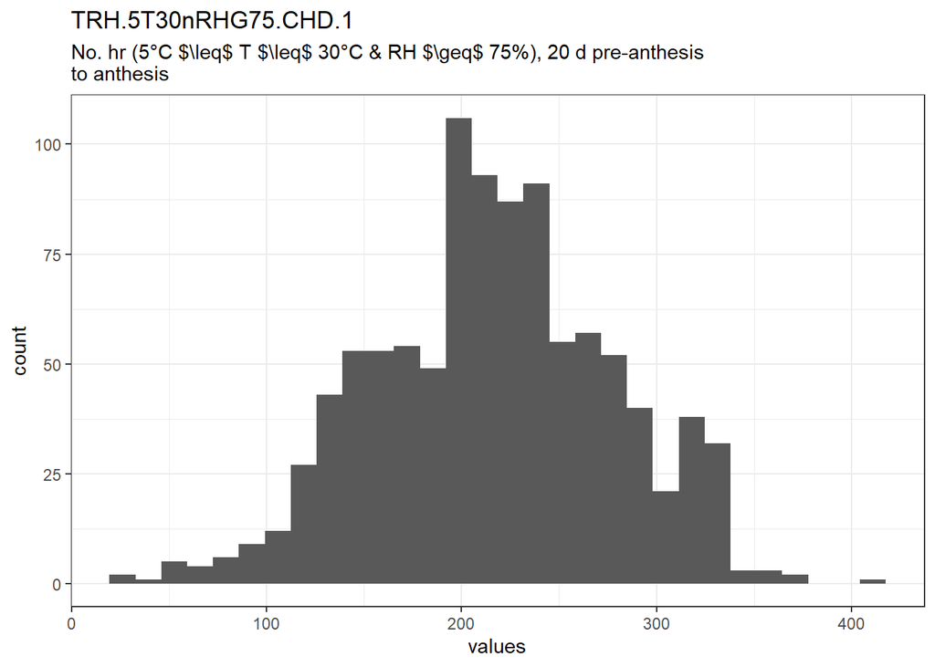

Distribution of values for TRH.5T30nRHG75.CHD.1

0 missing values.

#### Summary statistics

| name | label | data_type | n_missing | complete_rate | min | median | max | mean | sd | hist |
| --- | --- | --- | --- | --- | --- | --- | --- | --- | --- | --- |
| TRH.5T30nRHG75.CHD.1 | No. hr (5°C $\leq$ T $\leq$ 30°C & RH $\geq$ 75%), 20 d pre-anthesis to anthesis | numeric | 0 | 1 | 26 | 217 | 411 | 216.4104 | 61.17428 | ▁▅▇▅▁ |

### TRH.5T30nRHG75.CHD.2

No. hr (5°C $\leq$ T $\leq$ 30°C & RH $\geq$ 75%), 40 d pre-anthesis to anthesis

#### Distribution

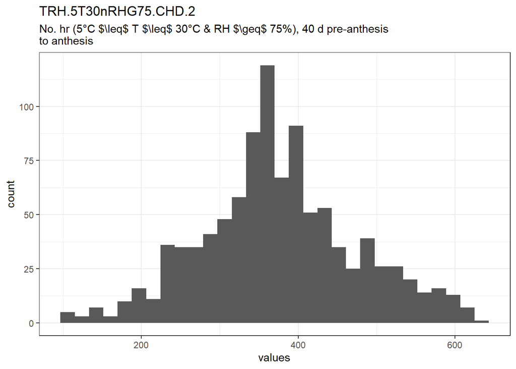

Distribution of values for TRH.5T30nRHG75.CHD.2

0 missing values.

#### Summary statistics

| name | label | data_type | n_missing | complete_rate | min | median | max | mean | sd | hist |
| --- | --- | --- | --- | --- | --- | --- | --- | --- | --- | --- |
| TRH.5T30nRHG75.CHD.2 | No. hr (5°C $\leq$ T $\leq$ 30°C & RH $\geq$ 75%), 40 d pre-anthesis to anthesis | numeric | 0 | 1 | 106 | 370 | 634 | 375.3163 | 99.24213 | ▁▃▇▃▂ |

### TRH.5T30nRHG75.CHD.3

No. hr (5°C $\leq$ T $\leq$ 30°C & RH $\geq$ 75%), anthesis to 10 d post-anthesis

#### Distribution

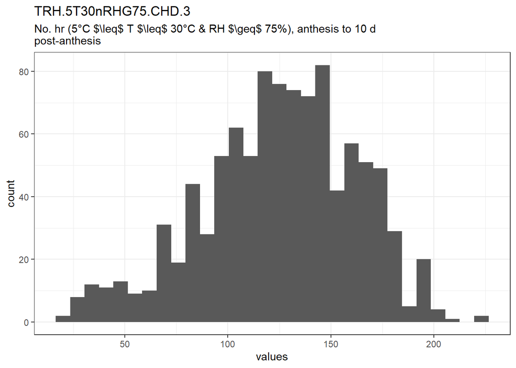

Distribution of values for TRH.5T30nRHG75.CHD.3

0 missing values.

#### Summary statistics

| name | label | data_type | n_missing | complete_rate | min | median | max | mean | sd | hist |
| --- | --- | --- | --- | --- | --- | --- | --- | --- | --- | --- |
| TRH.5T30nRHG75.CHD.3 | No. hr (5°C $\leq$ T $\leq$ 30°C & RH $\geq$ 75%), anthesis to 10 d post-anthesis | numeric | 0 | 1 | 20 | 127 | 223 | 125.1291 | 37.24977 | ▁▃▇▆▁ |

### TRH.9T30nRHG90.CHD.1

No. hr (9°C $\leq$ T $\leq$ 30°C & RH $\geq$ 90%), 30 d pre-anthesis to anthesis

#### Distribution

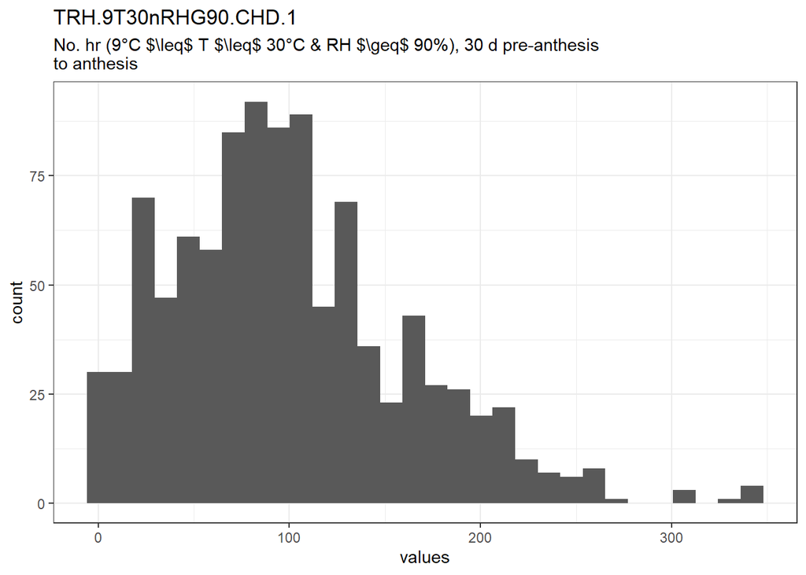

Distribution of values for TRH.9T30nRHG90.CHD.1

0 missing values.

#### Summary statistics

| name | label | data_type | n_missing | complete_rate | min | median | max | mean | sd | hist |
| --- | --- | --- | --- | --- | --- | --- | --- | --- | --- | --- |
| TRH.9T30nRHG90.CHD.1 | No. hr (9°C $\leq$ T $\leq$ 30°C & RH $\geq$ 90%), 30 d pre-anthesis to anthesis | numeric | 0 | 1 | 0 | 91 | 342 | 99.83884 | 61.85826 | ▆▇▃▁▁ |

### TRH.9T30nRHG90.CHD.2

No. hr (9°C $\leq$ T $\leq$ 30°C & RH $\geq$ 90%), 50 d pre-anthesis to anthesis

#### Distribution

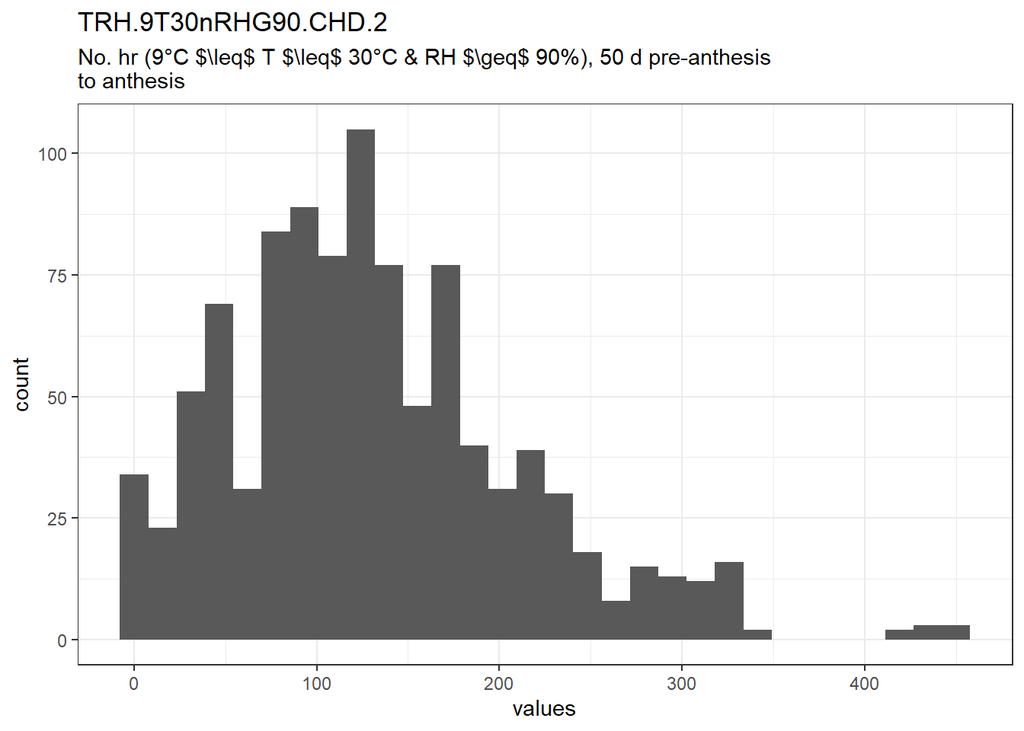

Distribution of values for TRH.9T30nRHG90.CHD.2

0 missing values.

#### Summary statistics

| name | label | data_type | n_missing | complete_rate | min | median | max | mean | sd | hist |
| --- | --- | --- | --- | --- | --- | --- | --- | --- | --- | --- |
| TRH.9T30nRHG90.CHD.2 | No. hr (9°C $\leq$ T $\leq$ 30°C & RH $\geq$ 90%), 50 d pre-anthesis to anthesis | numeric | 0 | 1 | 0 | 120 | 450 | 131.5906 | 79.54818 | ▆▇▃▁▁ |

### VPD.L11.CHD.1

No. hr (VPD $\leq$ 1.1 kPa), 15 d to 5 d pre-anthesis

#### Distribution

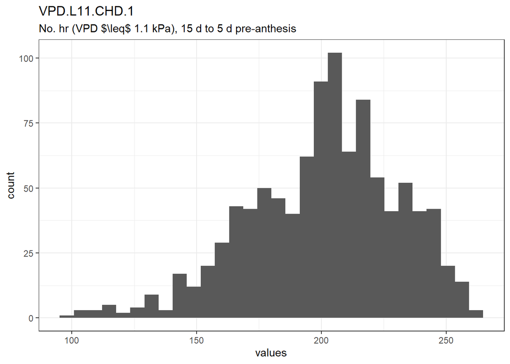

Distribution of values for VPD.L11.CHD.1

0 missing values.

#### Summary statistics

| name | label | data_type | n_missing | complete_rate | min | median | max | mean | sd | hist |
| --- | --- | --- | --- | --- | --- | --- | --- | --- | --- | --- |
| VPD.L11.CHD.1 | No. hr (VPD $\leq$ 1.1 kPa), 15 d to 5 d pre-anthesis | numeric | 0 | 1 | 98 | 203 | 262 | 200.7007 | 29.89104 | ▁▂▆▇▃ |

### VPD.L11.CHD.2

No. hr (VPD $\leq$ 1.1 kPa), 40 d pre-anthesis to anthesis

#### Distribution

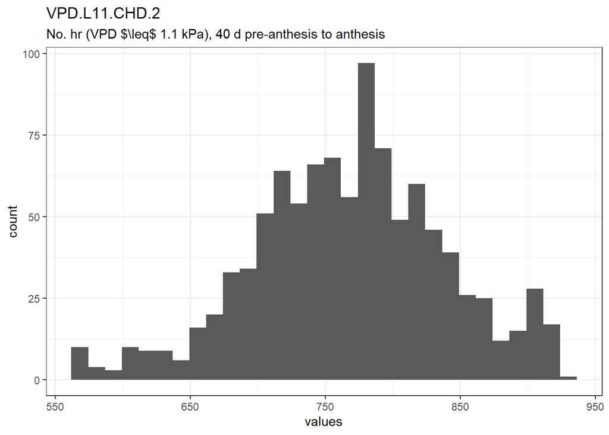

Distribution of values for VPD.L11.CHD.2

0 missing values.

#### Summary statistics

| name | label | data_type | n_missing | complete_rate | min | median | max | mean | sd | hist |
| --- | --- | --- | --- | --- | --- | --- | --- | --- | --- | --- |
| VPD.L11.CHD.2 | No. hr (VPD $\leq$ 1.1 kPa), 40 d pre-anthesis to anthesis | numeric | 0 | 1 | 568 | 772 | 930 | 767.6657 | 71.58338 | ▁▃▇▆▂ |

### VPD.L635.CHD.1

No. hr (VPD $\leq$ 0.635 kPa), 15 d to 5 d pre-anthesis

#### Distribution

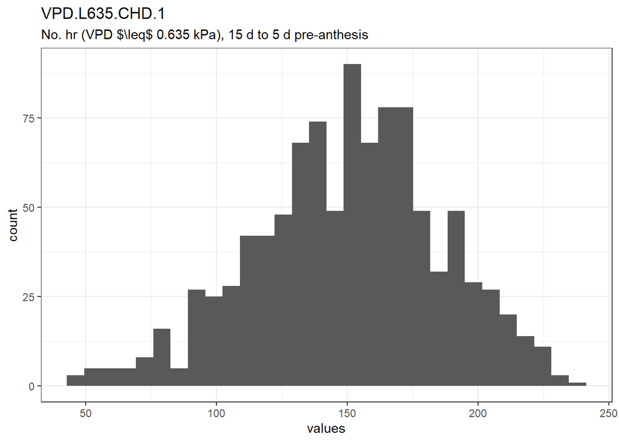

Distribution of values for VPD.L635.CHD.1

0 missing values.

#### Summary statistics

| name | label | data_type | n_missing | complete_rate | min | median | max | mean | sd | hist |
| --- | --- | --- | --- | --- | --- | --- | --- | --- | --- | --- |
| VPD.L635.CHD.1 | No. hr (VPD $\leq$ 0.635 kPa), 15 d to 5 d pre-anthesis | numeric | 0 | 1 | 46 | 152 | 238 | 150.2963 | 35.74383 | ▁▃▇▆▂ |

### VPD.L635.CHD.2

No. hr (VPD $\leq$ 0.635 kPa), 40 d pre-anthesis to 10 d post-anthesis

#### Distribution

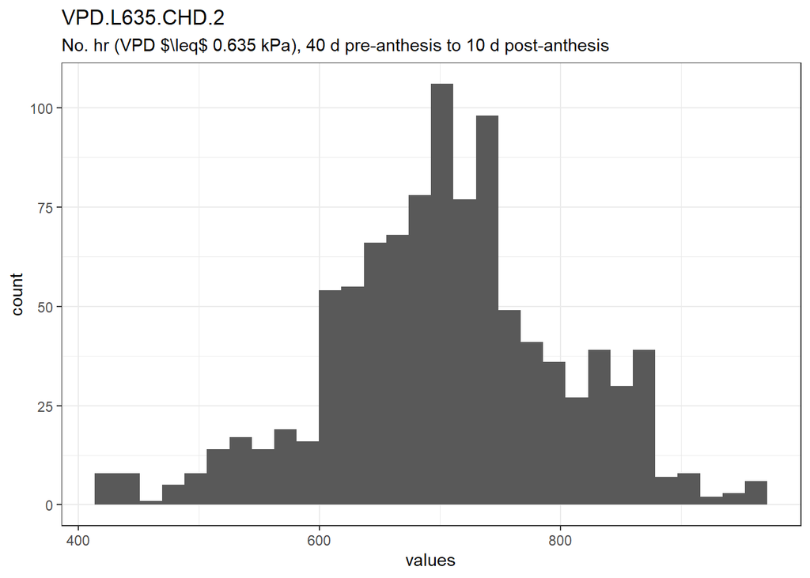

Distribution of values for VPD.L635.CHD.2

0 missing values.

#### Summary statistics

| name | label | data_type | n_missing | complete_rate | min | median | max | mean | sd | hist |
| --- | --- | --- | --- | --- | --- | --- | --- | --- | --- | --- |
| VPD.L635.CHD.2 | No. hr (VPD $\leq$ 0.635 kPa), 40 d pre-anthesis to 10 d post-anthesis | numeric | 0 | 1 | 423 | 704 | 962 | 705.1321 | 97.21029 | ▁▃▇▃▁ |

### RH.G70.CD.1

No. d (mean RH > 70%), 40 d to 10 d pre-anthesis

#### Distribution

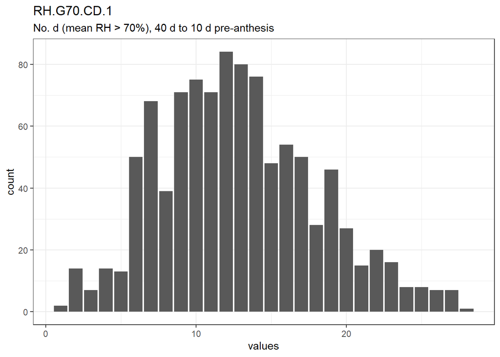

Distribution of values for RH.G70.CD.1

0 missing values.

#### Summary statistics

| name | label | data_type | n_missing | complete_rate | min | median | max | mean | sd | hist |
| --- | --- | --- | --- | --- | --- | --- | --- | --- | --- | --- |
| RH.G70.CD.1 | No. d (mean RH > 70%), 40 d to 10 d pre-anthesis | numeric | 0 | 1 | 1 | 12 | 28 | 12.82082 | 5.199519 | ▂▆▇▃▁ |

### RH.G70.CD.2

No. d (mean RH > 70%), anthesis to 10 d post-anthesis

#### Distribution

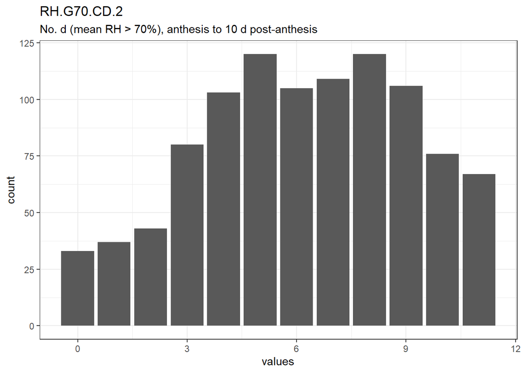

Distribution of values for RH.G70.CD.2

0 missing values.

#### Summary statistics

| name | label | data_type | n_missing | complete_rate | min | median | max | mean | sd | hist |
| --- | --- | --- | --- | --- | --- | --- | --- | --- | --- | --- |
| RH.G70.CD.2 | No. d (mean RH > 70%), anthesis to 10 d post-anthesis | numeric | 0 | 1 | 0 | 6 | 11 | 6.185185 | 2.910271 | ▃▆▇▇▇ |

### RH.G70.CD.3

No. d (mean RH > 70%), 15 d pre-anthesis to 10 d post-anthesis

#### Distribution

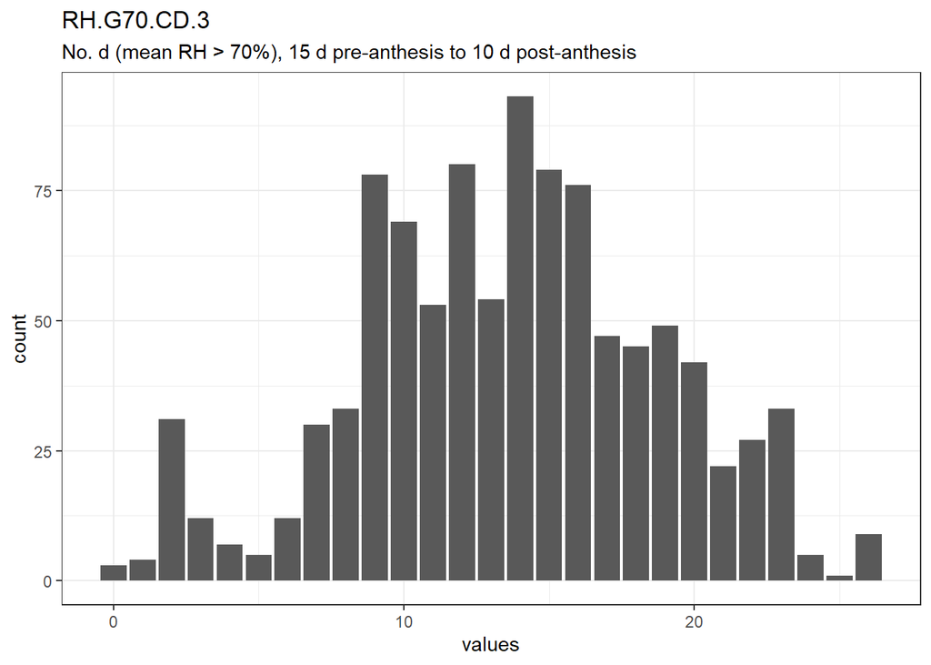

Distribution of values for RH.G70.CD.3

0 missing values.

#### Summary statistics

| name | label | data_type | n_missing | complete_rate | min | median | max | mean | sd | hist |
| --- | --- | --- | --- | --- | --- | --- | --- | --- | --- | --- |
| RH.G70.CD.3 | No. d (mean RH > 70%), 15 d pre-anthesis to 10 d post-anthesis | numeric | 0 | 1 | 0 | 14 | 26 | 13.62863 | 5.214557 | ▂▅▇▆▂ |

### T.14T22.CD.1

No. d (14°C < mean T < 22°C), 70 d pre-anthesis to anthesis

#### Distribution

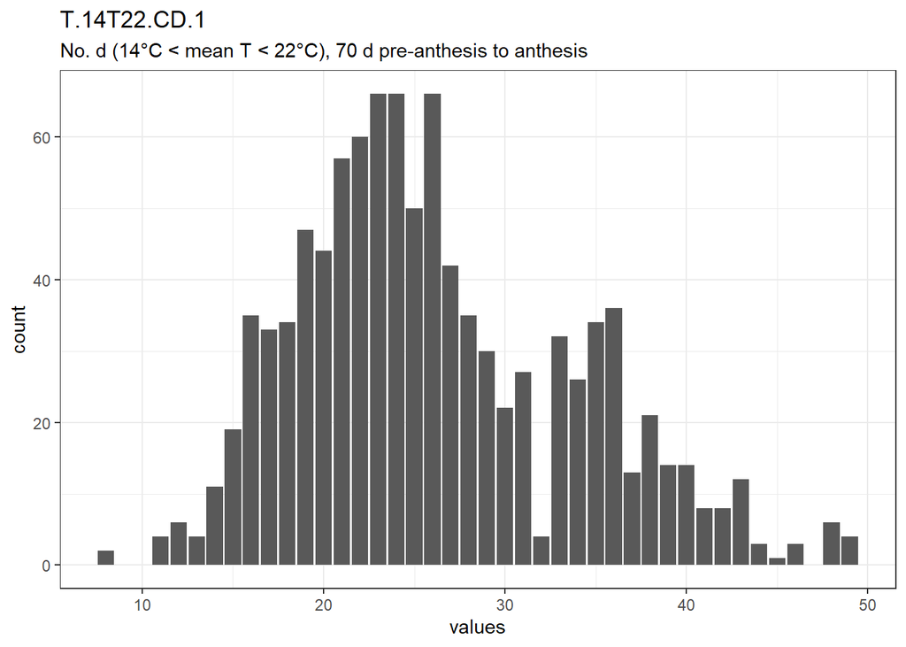

Distribution of values for T.14T22.CD.1

0 missing values.

#### Summary statistics

| name | label | data_type | n_missing | complete_rate | min | median | max | mean | sd | hist |
| --- | --- | --- | --- | --- | --- | --- | --- | --- | --- | --- |
| T.14T22.CD.1 | No. d (14°C < mean T < 22°C), 70 d pre-anthesis to anthesis | numeric | 0 | 1 | 8 | 25 | 49 | 26.13914 | 7.66127 | ▂▇▆▃▁ |

### T.14T22.CD.2

No. d (14°C < mean T < 22°C), 60 d to 40 d pre-anthesis

#### Distribution

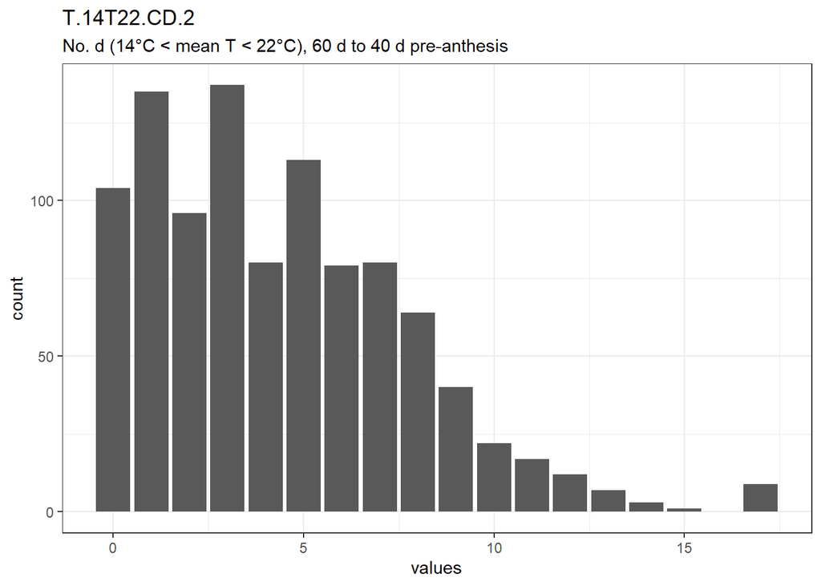

Distribution of values for T.14T22.CD.2

0 missing values.

#### Summary statistics

| name | label | data_type | n_missing | complete_rate | min | median | max | mean | sd | hist |
| --- | --- | --- | --- | --- | --- | --- | --- | --- | --- | --- |
| T.14T22.CD.2 | No. d (14°C < mean T < 22°C), 60 d to 40 d pre-anthesis | numeric | 0 | 1 | 0 | 4 | 17 | 4.385385 | 3.368876 | ▇▅▃▁▁ |